# MucoidEPS_Manuscript

Maria Alejandra Gil Polo

2026-06-23

#### Load packages

```r
library(performance)
library(lmerTest)
library(ggbeeswarm)
#library(glmmTMB)
library(here)
```

```r
library(ggplot2)
library(readxl)
library(dplyr)
library(writexl)
library(tidyverse)
library(remotes)
library(ggridges)
library(scales)
library(broom)
library(vcfR)
library(adegenet)
library(car)
library(multcomp)
#citation("car")
#citation("multcomp")
#citation("lmerTest")
#citation("vcfR")
```

#### Setting up the color pallette

```r
## What R version am I using##

R.version.string
```

```
## [1] "R version 4.4.2 (2024-10-31)"
```

```r
color_values <- c("Mucoid" = "#4eadb9",
                  "Dry" = "#e0ba3e",
                  "Mixture" = "#97b47c")

set.seed(123)
```

## Doing a PCA with the SNP variants

I am working with Sohini’s recent vcf file created with the alignment to reference genome 118. This is the link: https://github.com/sohini5981/AVT_SS/tree/main/Data and the name of the file is strain_118_variants.vcf.zip

```r
### Using the version with zip that is the one that got uploaded in Github

zip_path <- here("Genotype", "Data_input", "strain_118_variants.vcf.zip")
vcf_path <- here("Genotype", "Data_input", "strain_118_variants.vcf")

unzip(zip_path, exdir = here("Genotype", "Data_input"))

unlink(here("Genotype", "Data_input", "__MACOSX"), recursive = TRUE)

vcf <- read.vcfR(vcf_path)
```

[output not shown]

```r
#vcf <- read.vcfR(here("Genotype", "Data_input", "strain_118_variants.vcf")) ### I could not upload the .vcf file to github cause it was too heavy, so I uploaded the zipped version. Try to unzzip it and run it. The name is strain_118_variants.vcf.zip. I will keep this here and delete after review.

gt_reference <- extract.gt(vcf, element = "GT") ## 0 and 1
#gt_reference

gt_numeric <- apply(gt_reference, 2, as.numeric) #"2" tells R to look at the data by columns, and "as.numeric" changes the text to other values into numbers
#gt_numeric

rownames(gt_numeric) <- rownames(gt_reference) #Putting the names back
#gt_numeric

## PCA needs one row per strain (observation), one column per SNP (variable). The current matrix is the other way around, so I will transpose it.

gt_matrix <- t(gt_numeric)

#head(gt_matrix)

dim(gt_matrix) ## It shows 117 and 136566 #
```

```
## [1]    117 136566
```

```r
sum(is.na(gt_matrix)) #there are 762479 missing values ## handle the NAs because prcomp() can not handle NAs
```

```
## [1] 762479
```

```r
complete_snps <- colSums(is.na(gt_matrix)) == 0 ## Returns TRUE for columns that have zero missing values, this is a way to filter and keep only the complete columns
#complete_snps
gt_matrix <- gt_matrix[,complete_snps] ## Here I am retaining only the columns that do not have any missing data.
dim(gt_matrix) # 117 and 96206
```

```
## [1]   117 96206
```

```r
### Run the PCA ###

pca_result <- prcomp(gt_matrix, center = TRUE, scale. = FALSE)

pca_summary <- summary(pca_result)$importance
pca_summary
```

```
##                             PC1      PC2      PC3      PC4      PC5      PC6
## Standard deviation     53.19617 34.19934 26.28576 22.90306 17.69299 17.25006
## Proportion of Variance  0.42551  0.17587  0.10389  0.07887  0.04707  0.04474
## Cumulative Proportion   0.42551  0.60138  0.70528  0.78415  0.83122  0.87597
##                             PC7      PC8      PC9     PC10     PC11     PC12
## Standard deviation     14.82543 12.20910 10.45625 10.01110 7.528624 6.273986
## Proportion of Variance  0.03305  0.02241  0.01644  0.01507 0.008520 0.005920
## Cumulative Proportion   0.90902  0.93143  0.94787  0.96294 0.971460 0.977380
##                           PC13    PC14     PC15     PC16     PC17     PC18
## Standard deviation     5.62163 5.47824 4.483234 3.944822 3.559815 2.557169
## Proportion of Variance 0.00475 0.00451 0.003020 0.002340 0.001910 0.000980
## Cumulative Proportion  0.98213 0.98665 0.989670 0.992010 0.993910 0.994900
##                            PC19     PC20     PC21     PC22    PC23     PC24
## Standard deviation     1.553994 1.404799 1.234994 1.147043 1.13180 1.007592
## Proportion of Variance 0.000360 0.000300 0.000230 0.000200 0.00019 0.000150
## Cumulative Proportion  0.995260 0.995560 0.995790 0.995980 0.99618 0.996330
##                             PC25      PC26      PC27      PC28      PC29
## Standard deviation     0.9859874 0.9109311 0.8886404 0.8838538 0.8767845
## Proportion of Variance 0.0001500 0.0001200 0.0001200 0.0001200 0.0001200
## Cumulative Proportion  0.9964800 0.9966000 0.9967200 0.9968400 0.9969500
##                             PC30      PC31      PC32      PC33      PC34
## Standard deviation     0.8716883 0.8547731 0.8348234 0.8159082 0.8043471
## Proportion of Variance 0.0001100 0.0001100 0.0001000 0.0001000 0.0001000
## Cumulative Proportion  0.9970700 0.9971800 0.9972800 0.9973800 0.9974800
##                             PC35      PC36      PC37      PC38      PC39
## Standard deviation     0.7933084 0.7666189 0.7588076 0.7550829 0.7481371
## Proportion of Variance 0.0000900 0.0000900 0.0000900 0.0000900 0.0000800
## Cumulative Proportion  0.9975700 0.9976600 0.9977500 0.9978300 0.9979200
##                            PC40      PC41      PC42      PC43      PC44
## Standard deviation     0.733125 0.7168013 0.7080209 0.7032546 0.6886543
## Proportion of Variance 0.000080 0.0000800 0.0000800 0.0000700 0.0000700
## Cumulative Proportion  0.998000 0.9980800 0.9981500 0.9982300 0.9983000
##                             PC45      PC46      PC47      PC48      PC49
## Standard deviation     0.6750698 0.6682745 0.6568448 0.6512749 0.6407549
## Proportion of Variance 0.0000700 0.0000700 0.0000600 0.0000600 0.0000600
## Cumulative Proportion  0.9983700 0.9984300 0.9985000 0.9985600 0.9986200
##                             PC50      PC51      PC52      PC53      PC54
## Standard deviation     0.6304863 0.6154601 0.6052193 0.5953011 0.5818581
## Proportion of Variance 0.0000600 0.0000600 0.0000600 0.0000500 0.0000500
## Cumulative Proportion  0.9986800 0.9987400 0.9987900 0.9988500 0.9989000
```

[output cut: 37 more lines]

```
## Standard deviation     0.1949372 0.1888119 0.1854254 0.182037 0.1750887
## Proportion of Variance 0.0000100 0.0000100 0.0000100 0.000000 0.0000000
## Cumulative Proportion  0.9999500 0.9999500 0.9999600 0.999960 0.9999700
##                            PC105     PC106     PC107     PC108     PC109
## Standard deviation     0.1723212 0.1642327 0.1624336 0.1572395 0.1526961
## Proportion of Variance 0.0000000 0.0000000 0.0000000 0.0000000 0.0000000
## Cumulative Proportion  0.9999700 0.9999700 0.9999800 0.9999800 0.9999900
##                            PC110     PC111     PC112     PC113     PC114
## Standard deviation     0.1399974 0.1369053 0.1314565 0.1239932 0.1181587
## Proportion of Variance 0.0000000 0.0000000 0.0000000 0.0000000 0.0000000
## Cumulative Proportion  0.9999900 0.9999900 0.9999900 1.0000000 1.0000000
##                             PC115      PC116       PC117
## Standard deviation     0.09284767 0.04481543 2.91351e-12
## Proportion of Variance 0.00000000 0.00000000 0.00000e+00
## Cumulative Proportion  1.00000000 1.00000000 1.00000e+00
```

```r
round(pca_summary["Proportion of Variance", ]*100,2)[1]
```

```
##   PC1
## 42.55
```

```r
pca_table <- data.frame(
  PC = colnames(pca_summary),
  Percent_Variance = round(pca_summary["Proportion of Variance", ] * 100, 2))
pca_table
```

```
##          PC Percent_Variance
## PC1     PC1            42.55
## PC2     PC2            17.59
## PC3     PC3            10.39
## PC4     PC4             7.89
## PC5     PC5             4.71
## PC6     PC6             4.47
## PC7     PC7             3.31
## PC8     PC8             2.24
## PC9     PC9             1.64
## PC10   PC10             1.51
## PC11   PC11             0.85
## PC12   PC12             0.59
## PC13   PC13             0.48
## PC14   PC14             0.45
## PC15   PC15             0.30
## PC16   PC16             0.23
## PC17   PC17             0.19
## PC18   PC18             0.10
## PC19   PC19             0.04
## PC20   PC20             0.03
## PC21   PC21             0.02
## PC22   PC22             0.02
## PC23   PC23             0.02
## PC24   PC24             0.01
## PC25   PC25             0.01
## PC26   PC26             0.01
## PC27   PC27             0.01
## PC28   PC28             0.01
## PC29   PC29             0.01
## PC30   PC30             0.01
## PC31   PC31             0.01
## PC32   PC32             0.01
## PC33   PC33             0.01
## PC34   PC34             0.01
## PC35   PC35             0.01
## PC36   PC36             0.01
## PC37   PC37             0.01
## PC38   PC38             0.01
## PC39   PC39             0.01
```

[output cut: 63 more lines]

```
## PC103 PC103             0.00
## PC104 PC104             0.00
## PC105 PC105             0.00
## PC106 PC106             0.00
## PC107 PC107             0.00
## PC108 PC108             0.00
## PC109 PC109             0.00
## PC110 PC110             0.00
## PC111 PC111             0.00
## PC112 PC112             0.00
## PC113 PC113             0.00
## PC114 PC114             0.00
## PC115 PC115             0.00
## PC116 PC116             0.00
## PC117 PC117             0.00
```

```r
pca_table_top10 <- pca_table %>% #The proportion of varance is the same than pca_result$sdev^2, and then (pc_variance/sum(pc_variance))*100
  slice_max(order_by = Percent_Variance, n = 10)

pca_table_top10
```

```
##        PC Percent_Variance
## PC1   PC1            42.55
## PC2   PC2            17.59
## PC3   PC3            10.39
## PC4   PC4             7.89
## PC5   PC5             4.71
## PC6   PC6             4.47
## PC7   PC7             3.31
## PC8   PC8             2.24
## PC9   PC9             1.64
## PC10 PC10             1.51
```

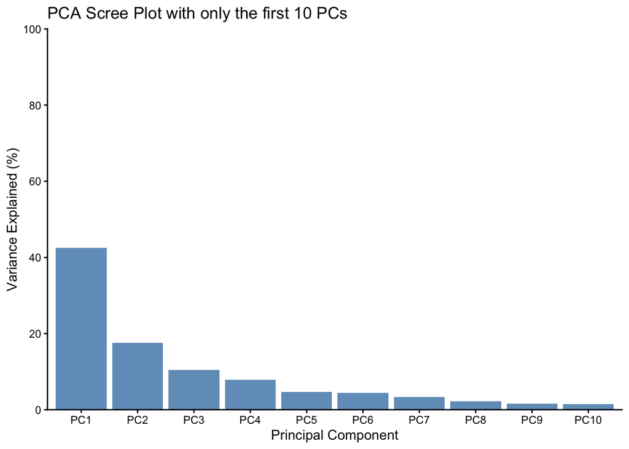

```r
write_xlsx(pca_table_top10, here("Phenotype", "Tables", "EPS_TableS1_FromR.xlsx"))

pca_table_top10$PC <- factor(pca_table_top10$PC, levels = c("PC1", "PC2", "PC3", "PC4", "PC5", "PC6", "PC7", "PC8", "PC9", "PC10"))


#scree_data #
screeplot <- ggplot(pca_table_top10, aes(x = PC, y = Percent_Variance)) +
  geom_bar(stat = "identity", fill = "steelblue", alpha = 0.8) +   # Draw the background bars
    scale_y_continuous(limits = c(0, 100), breaks = seq(0, 100, 20), expand = c(0, 0)) +
  labs(
    title = "PCA Scree Plot with only the first 10 PCs",
    x = "Principal Component",
    y = "Variance Explained (%)"
  ) +
  theme_classic()

screeplot
```

```r
ggsave(here("Phenotype", "Figures", "EPS_FigureS1A_FromR.pdf"), screeplot, width = 4, height = 2.5, units = "in")

# Get the pc_scores

## I will use the pc_scores

pc_scores <- as.data.frame(pca_result$x)

pc_scores <- rownames_to_column(pc_scores, var = "Strain_Code")
pc_scores #PC1 and PC2 will be incorporated as fixed-effect variables in statistical models that indicate this
```

```
##     Strain_Code        PC1           PC2        PC3        PC4         PC5
## 1          AVT1 -69.572604 -31.004288286  23.659093 -14.828496   0.2454651
## 2         AVT10 -69.666095 -31.000389061  23.569641 -14.756337   0.4902608
## 3        AVT100 -43.655626  -8.719093558 -25.277155  61.586855 -23.6319738
## 4        AVT101  13.059359  -6.085610982 -14.391384  16.585434  33.2810985
## 5        AVT102 -34.664552  -8.946272349 -11.935505  21.384665  14.6726340
## 6        AVT103 -69.755894 -30.992970479  23.502795 -14.584879   0.4082426
## 7        AVT104  54.256736  -1.470902908   3.560982  -3.193457  -0.8049454
## 8        AVT105 -60.863271 201.416740803 103.641434  35.706887  22.4791034
## 9        AVT106 -28.393651  61.498017452  -6.943357 -22.346003 -59.1660065
## 10       AVT107  53.953308  -1.517588222   3.426183  -3.114200  -0.7667023
## 11       AVT108 -27.847795 -10.948165379 -10.721281  22.189796  47.4463391
## 12       AVT109 -28.598653  -0.008189746 -14.028017   5.425579  15.3589663
## 13        AVT11  54.040287  -1.502787059   3.464747  -3.139169  -0.7873519
## 14       AVT110 -43.718874  -8.728564597 -25.243137  61.161858 -23.2993227
```

[output cut: 2817 more lines]

```r
### I will merge this data with the morphology data to be able to color them based on "Morphology"

Strains <- read_excel(here("Genotype", "Data_input", "Strains_Description_Phenotype_Github.xlsx"))
Strains
```

```
## # A tibble: 117 × 4
##    Strain_Code Strain Morphology Pairs
##    <chr>       <chr>  <chr>      <dbl>
##  1 AVT1        001    Mucoid        NA
##  2 AVT2        002    Mucoid        NA
##  3 AVT3        003    Mucoid         6
##  4 AVT4        004    Mucoid         7
##  5 AVT5        005    Mucoid        NA
##  6 AVT6        006    Mucoid        NA
##  7 AVT7        007    Mucoid        NA
##  8 AVT8        008    Mucoid        NA
##  9 AVT9        009    Mucoid        NA
## 10 AVT10       010    Mucoid        NA
## # ℹ 107 more rows
```

```r
### Merge

Strain_morphotype <- merge(Strains, pc_scores, by = "Strain_Code")
Strain_morphotype
```

```
##     Strain_Code Strain Morphology Pairs        PC1           PC2        PC3
## 1          AVT1    001     Mucoid    NA -69.572604 -31.004288286  23.659093
## 2         AVT10    010     Mucoid    NA -69.666095 -31.000389061  23.569641
## 3        AVT100    100        Dry     3 -43.655626  -8.719093558 -25.277155
## 4        AVT101    101        Dry     4  13.059359  -6.085610982 -14.391384
## 5        AVT102    102        Dry     5 -34.664552  -8.946272349 -11.935505
## 6        AVT103    103        Dry     6 -69.755894 -30.992970479  23.502795
## 7        AVT104    104        Dry     7  54.256736  -1.470902908   3.560982
## 8        AVT105    105        Dry     8 -60.863271 201.416740803 103.641434
## 9        AVT106    106        Dry     9 -28.393651  61.498017452  -6.943357
## 10       AVT107    107        Dry    10  53.953308  -1.517588222   3.426183
## 11       AVT108    108        Dry    11 -27.847795 -10.948165379 -10.721281
## 12       AVT109    109        Dry    NA -28.598653  -0.008189746 -14.028017
## 13        AVT11    011     Mucoid    NA  54.040287  -1.502787059   3.464747
## 14       AVT110    110        Dry    NA -43.718874  -8.728564597 -25.243137
```

[output cut: 2817 more lines]

```r
### This file cointains the information about the phylogenetically relatedness, I will store it
write_csv(Strain_morphotype, here("Phenotype", "Tables", "PCA_scores_strains.csv"))



## Plot
var_explained <- (pca_result$sdev^2) / sum(pca_result$sdev^2)
var_explained
```

```
##   [1] 4.255128e-01 1.758682e-01 1.038946e-01 7.887494e-02 4.707109e-02
##   [6] 4.474383e-02 3.304963e-02 2.241398e-02 1.644008e-02 1.507008e-02
##  [11] 8.522817e-03 5.918873e-03 4.752000e-03 4.512674e-03 3.022280e-03
##  [16] 2.339951e-03 1.905490e-03 9.832652e-04 3.631205e-04 2.967429e-04
##  [21] 2.293411e-04 1.978389e-04 1.926155e-04 1.526587e-04 1.461823e-04
##  [26] 1.247737e-04 1.187419e-04 1.174662e-04 1.155946e-04 1.142548e-04
##  [31] 1.098635e-04 1.047952e-04 1.001001e-04 9.728344e-05 9.463156e-05
##  [36] 8.837124e-05 8.657953e-05 8.573166e-05 8.416167e-05 8.081797e-05
##  [41] 7.725907e-05 7.537792e-05 7.436645e-05 7.131067e-05 6.852503e-05
##  [46] 6.715243e-05 6.487502e-05 6.377942e-05 6.173562e-05 5.977275e-05
##  [51] 5.695761e-05 5.507790e-05 5.328749e-05 5.090801e-05 4.861215e-05
##  [56] 4.706645e-05 4.609248e-05 4.406283e-05 4.277074e-05 4.126744e-05
##  [61] 4.034525e-05 3.944678e-05 3.863411e-05 3.740495e-05 3.708201e-05
##  [66] 3.590791e-05 3.412420e-05 3.085527e-05 3.026751e-05 3.019477e-05
##  [71] 2.813234e-05 2.660869e-05 2.592523e-05 2.544830e-05 2.472013e-05
##  [76] 2.295335e-05 2.135042e-05 1.872199e-05 1.765727e-05 1.712944e-05
##  [81] 1.650887e-05 1.576494e-05 1.425612e-05 1.344208e-05 1.291047e-05
##  [86] 1.183033e-05 1.066247e-05 9.867335e-06 9.354486e-06 9.077676e-06
##  [91] 8.371417e-06 8.134552e-06 7.856432e-06 7.618337e-06 7.196560e-06
##  [96] 6.892080e-06 6.771498e-06 6.122302e-06 6.010274e-06 5.714013e-06
## [101] 5.360566e-06 5.170000e-06 4.982777e-06 4.609652e-06 4.465080e-06
## [106] 4.055752e-06 3.967379e-06 3.717707e-06 3.505968e-06 2.947078e-06
## [111] 2.818333e-06 2.598460e-06 2.311786e-06 2.099344e-06 1.296265e-06
## [116] 3.020001e-07 1.276395e-27
```

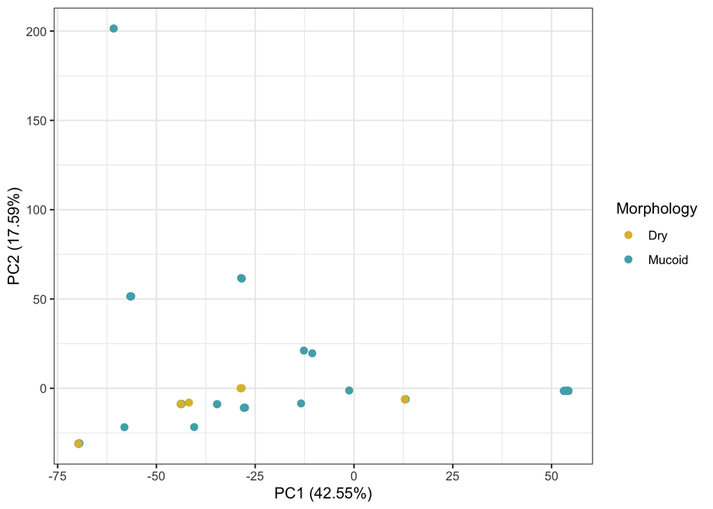

```r
PCA <- ggplot(merge(Strains, pc_scores, by = "Strain_Code"), aes(x = PC1, y = PC2, color = Morphology)) +
  geom_point(size = 2) +
  scale_color_manual(values = c("Mucoid" = "#4eadb9",
                  "Dry" = "#e0ba3e")) +
  xlab(paste0("PC1 (", round(pca_summary["Proportion of Variance", ]*100,2)[1], "%)")) + #42.6
  ylab(paste0("PC2 (", round(pca_summary["Proportion of Variance", ]*100,2)[2], "%)")) + #17.6
  theme_bw()
PCA
```

```r
ggsave(plot = PCA, here("Phenotype", "Figures", "EPS_FigureS1B_FromR.pdf"),
            width = 6, height = 2.5, units = "in")
```

### Co-occurrence

We used 4 pairs (each pair is a mucoid a dry strain that were co-isolated together), to co-inoculate alfalfa plants variety “Oneida”. We had 7 reps per co-inoculation. We picked the nodules of each plant and randomly chose 10 nodules per plant. We then disinfected, crushed, resuspended and plated each nodule in Yeast Manitol Agar (YEMA)

```r
Individual_nodule_data <- read.csv(here("Phenotype", "Data_input", "SingleNodule_Ocurrence_data.csv"))
#View(Individual_nodule_data)
Individual_nodule_data <- Individual_nodule_data %>% filter(Morphology %in% c("Dry", "Mucoid", "Mixture")) #Remove contaminants and morphologies that did not have a clear morphology. The percentages are therefore calculated with respect of the total nodules where we could extract data
Individual_nodule_data
```

```
##        Name Plant Growth_chamber Nodule       Lobed Morphology
## 1   091_101     1              1      1           2     Mucoid
## 2   091_101     1              1      3           1     Mucoid
## 3   091_101     1              1      4           2     Mucoid
## 4   091_101     1              1      6           1    Mixture
## 5   091_101     1              1      7           2        Dry
## 6   091_101     1              1      8           1        Dry
## 7   091_101     1              1      9           1     Mucoid
## 8   091_101     1              1     10           1     Mucoid
## 9   015_099     1              1      1           1     Mucoid
## 10  015_099     1              1      2           2     Mucoid
## 11  015_099     1              1      3           3        Dry
## 12  015_099     1              1      5           1     Mucoid
## 13  015_099     1              1      7           1     Mucoid
## 14  015_099     1              1      8           1        Dry
```

[output cut: 211 more lines]

```r
### Create a table that shows the proportions of each morphology in the nodules

function_pair <- function(Partner) {c(
  Name = Partner,
  nrow(Individual_nodule_data %>% filter(Name == Partner)),
  sprintf("%.3f", 100*nrow(Individual_nodule_data %>% filter(Name == Partner & Morphology == "Mucoid"))/nrow(Individual_nodule_data %>% filter(Name == Partner))),
  sprintf("%.3f", 100*nrow(Individual_nodule_data %>% filter(Name == Partner & Morphology == "Dry"))/nrow(Individual_nodule_data %>% filter(Name == Partner))),
  sprintf("%.3f", 100*nrow(Individual_nodule_data %>% filter(Name == Partner & Morphology == "Mixture"))/nrow(Individual_nodule_data %>% filter(Name == Partner))))
}

#Pair 091_101
function_pair("091_101")
```

```
##      Name
## "091_101"      "58"  "68.966"  "22.414"   "8.621"
```

```r
Table_mix_percentage <- rbind(function_pair("091_101"), function_pair("015_099"), function_pair("016_100"), function_pair("029_098"))
Table_mix_percentage <- as.data.frame(Table_mix_percentage)
Table_mix_percentage
```

```
##      Name V2     V3     V4     V5
## 1 091_101 58 68.966 22.414  8.621
## 2 015_099 52 36.538 46.154 17.308
## 3 016_100 65 49.231 33.846 16.923
## 4 029_098 50 18.000 56.000 26.000
```

```r
colnames(Table_mix_percentage) <- c("Pair", "Number of nodules", "% Mucoid", "% Dry", "% Mixture")

Table_mix_percentage
```

```
##      Pair Number of nodules % Mucoid  % Dry % Mixture
## 1 091_101                58   68.966 22.414     8.621
## 2 015_099                52   36.538 46.154    17.308
## 3 016_100                65   49.231 33.846    16.923
## 4 029_098                50   18.000 56.000    26.000
```

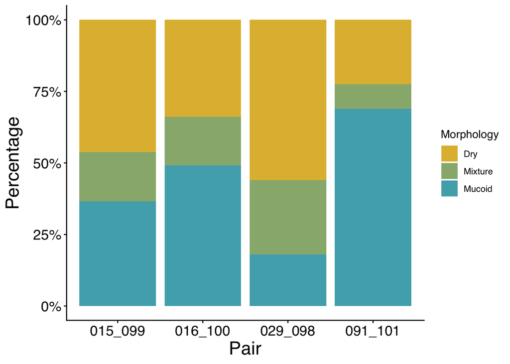

```r
write_xlsx(Table_mix_percentage, here("Phenotype" , "Tables", "EPS_TableS2_FromR.xlsx"))

## Total number of nodules with mixture and with single

## Total of nodules with valid assessment (taking out the contaminations). The results suggest that from 225 nodules, 83% have a single morphology, either mucoid or dry, wherease mixtures occupy around 17% of the nodules. The data broken down is in the upper part.


## Plot
#View(Individual_nodule_data)
coocurrence <- ggplot(Individual_nodule_data,
       aes(x = Name, fill = Morphology)) +
  geom_bar(position = "fill") +
  scale_fill_manual(values = color_values)+
    scale_y_continuous(labels = scales::percent) +
  labs(x = "Pair", y = "Percentage")+
    theme_classic() +
  theme(
    text             = element_text(family = "Helvetica", color = "black"),
    axis.text        = element_text(size = 14, color = "black"),
    axis.title.x     = element_text(size = 18, color = "black"),
    axis.title.y     = element_text(size = 18, color = "black"),
    panel.grid.minor       = element_blank(),
    panel.grid.major = element_blank(),
    axis.line        = element_line(color = "black"),
    axis.ticks       = element_line(color = "black"))

coocurrence
```

```r
ggsave(coocurrence,
       filename = here("Phenotype", "Figures" ,"EPS_FigureS2B_FromR.pdf"),
       device = "pdf",
       height = 4, width = 6, units = "in")
```

### Exopolysaccharide description

Anthrone assay

For the Anthrone assay experiment, I grew 116 strains of Sinorhizobium meliloti in RDM liquid media for 8 days. Then I centrifuged the samples, and recovered the supernatant, diluted it to 1:50 and then used the dilution to run the anthrone assay. To estimate the biomass content, resuspended the pellet in saline solution to measure the OD600 so I could normalize data to the OD600.

```r
Oct2025_AnthroneOD620 <- read_excel(here("Phenotype", "Data_input", "AnthroneOD620.xlsx"))


## Substract the Blanks labeled as "Bla" from the OD620 measurements.

Anthrone620 <- Oct2025_AnthroneOD620 %>%
  mutate(OD620_Adj = OD620 - mean(OD620[Name == "Blank"], na.rm = TRUE))

## Calculate the amount of glucose produced by each strain using the calibration curve.

Glucose_standards <- Anthrone620 %>% filter(Morphology == "Calibration") ## Filter Morphology > Calibration

Glucose_standards <- Glucose_standards %>%
  mutate(Glucose_quantity = case_when(
    Strain == "Glu1" ~ 20, #ug
    Strain == "Glu2" ~ 10, #ug
    Strain == "Glu3" ~ 5, #ug
    Strain == "Glu4" ~ 2.5, #ug
    Strain == "Glu5" ~ 1.25, #ug
    Strain == "Glu6" ~ 0.625, #ug
    Strain == "Glu7" ~ 0.3125, #ug
    Strain == "Glu8" ~ 0.15625, #ug
    TRUE ~ NA_real_  # Default case if no match is found
  ))


## I will extract the coefficients to create a linear formula and apply that to my current values

model <- lm(Glucose_quantity ~ OD620_Adj, data= Glucose_standards)
summary(model)
```

```
##
## Call:
## lm(formula = Glucose_quantity ~ OD620_Adj, data = Glucose_standards)
##
## Residuals:
##      Min       1Q   Median       3Q      Max
## -2.00217 -0.47122  0.04357  0.34418  2.48313
##
## Coefficients:
##             Estimate Std. Error t value Pr(>|t|)
## (Intercept)  -0.2921     0.2462  -1.186    0.249
## OD620_Adj    50.5936     1.4692  34.436   <2e-16 ***
## ---
## Signif. codes:  0 '***' 0.001 '**' 0.01 '*' 0.05 '.' 0.1 ' ' 1
##
## Residual standard error: 0.9034 on 21 degrees of freedom
## Multiple R-squared:  0.9826, Adjusted R-squared:  0.9818
## F-statistic:  1186 on 1 and 21 DF,  p-value: < 2.2e-16
```

```r
coefficients <- coef(model)

b_intercept <- coefficients["(Intercept)"]
b_intercept #  -0.2920703
```

```
## (Intercept)
##  -0.2920703
```

```r
a_slope <- coefficients["OD620_Adj"]
a_slope #50.59358
```

```
## OD620_Adj
##  50.59358
```

```r
## Filter out the Blank and the ones that have Glu but are not useful for the calibration

Anthrone620_strains <- Anthrone620 %>% filter(!(Strain == "Bla" | grepl("Glu", Strain)))
Anthrone620_strains
```

```
## # A tibble: 341 × 6
##    Name  OD620 Strain Rep   Morphology OD620_Adj
##    <chr> <dbl> <chr>  <chr> <chr>          <dbl>
##  1 001.1 0.181 001    1     Mucoid         0.131
##  2 001.2 0.202 001    2     Mucoid         0.152
##  3 001.3 0.197 001    3     Mucoid         0.147
##  4 002.1 0.206 002    1     Mucoid         0.156
##  5 002.2 0.198 002    2     Mucoid         0.148
##  6 002.3 0.197 002    3     Mucoid         0.147
##  7 003.1 0.213 003    1     Mucoid         0.163
##  8 003.3 0.14  003    3     Mucoid         0.09
##  9 004.1 0.196 004    1     Mucoid         0.146
## 10 004.2 0.134 004    2     Mucoid         0.084
## # ℹ 331 more rows
```

```r
OD620_strains <- Anthrone620_strains %>%
  mutate(Glucose_quantity = a_slope*OD620_Adj + b_intercept)

### Calculate the OD600

Oct2025_AnthroneOD600 <- read_excel(here("Phenotype", "Data_input", "AnthroneOD600.xlsx"))


Anthrone600 <- Oct2025_AnthroneOD600 %>%
  mutate(OD600_Adj = OD600 - mean(OD600[Name == "Blank"], na.rm = TRUE))

Anthrone600_strains <- Anthrone600 %>% filter(Name != "Blank")

Anthrone600_strains <-  Anthrone600_strains %>%
  group_by(Name) %>%
  summarise(OD600_Adj_mean = mean(OD600_Adj)) ## Since I have two measurements per rep, I will find the mean od the OD600_Adj

Anthrone600_strains
```

```
## # A tibble: 345 × 2
##    Name  OD600_Adj_mean
##    <chr>          <dbl>
##  1 001.1          0.220
##  2 001.2          0.377
##  3 001.3          0.371
##  4 002.1          0.224
##  5 002.2          0.324
##  6 002.3          0.489
##  7 003.1          0.232
##  8 003.2          0.241
##  9 003.3          0.252
## 10 004.1          0.268
## # ℹ 335 more rows
```

```r
### I will now merge the files

Anthrone <- merge(OD620_strains, Anthrone600_strains, by = "Name")
Anthrone <- Anthrone %>%
  mutate(
    Strain = as.character(Strain),
    Name   = as.character(Name)
  )


Anthrone_complete <- Anthrone %>%
  mutate(Glucose_OD600 = Glucose_quantity/OD600_Adj_mean)
Anthrone_complete
```

```
##      Name OD620 Strain Rep Morphology OD620_Adj Glucose_quantity OD600_Adj_mean
## 1   001.1 0.181    001   1     Mucoid     0.131       6.33568910   0.2197552288
## 2   001.2 0.202    001   2     Mucoid     0.152       7.39815435   0.3772611111
## 3   001.3 0.197    001   3     Mucoid     0.147       7.14518643   0.3713611111
## 4   002.1 0.206    002   1     Mucoid     0.156       7.60052868   0.2239316993
## 5   002.2 0.198    002   2     Mucoid     0.148       7.19578001   0.3243111111
## 6   002.3 0.197    002   3     Mucoid     0.147       7.14518643   0.4892611111
## 7   003.1 0.213    003   1     Mucoid     0.163       7.95468376   0.2322846405
## 8   003.2 0.098    003   2     Mucoid     0.048       2.13642168   0.2406111111
## 9   003.3 0.140    003   3     Mucoid     0.090       4.26135218   0.2519611111
## 10  004.1 0.196    004   1     Mucoid     0.146       7.09459285   0.2680199346
## 11  004.2 0.134    004   2     Mucoid     0.084       3.95779068   0.3518611111
## 12  004.3 0.138    004   3     Mucoid     0.088       4.16016501   0.3565111111
## 13  005.1 0.188    005   1     Mucoid     0.138       6.68984418   0.2648728758
## 14  005.2 0.122    005   2     Mucoid     0.072       3.35066768   0.3009611111
```

[output cut: 665 more lines]

```r
#### Filtering ####

## Strain 121 did not grow in the RDM media, therefore I will remove them from the file

Anthrone_complete <- Anthrone_complete %>% filter(Strain != "121")

write_csv(Anthrone_complete, here("Phenotype", "Tables", "Anthrone_complete.csv"))


## Calculate the mean of each strain and not only of each tube (technical replicate)
Anthrone_mean <- Anthrone_complete %>%
  group_by(Strain, Morphology) %>%
  summarise(Glucose_OD600_ave = mean(Glucose_OD600))
```

```
## `summarise()` has regrouped the output.
## ℹ Summaries were computed grouped by Strain and Morphology.
## ℹ Output is grouped by Strain.
## ℹ Use `summarise(.groups = "drop_last")` to silence this message.
## ℹ Use `summarise(.by = c(Strain, Morphology))` for per-operation grouping
##   (`?dplyr::dplyr_by`) instead.
```

```r
write_csv(Anthrone_mean, here("Phenotype", "Tables", "Anthrone_mean.csv"))
```

#### Anthrone per pair - Figure

## Assess whether mucoid bacteria have higher EPS production disregarding of the Pair

```r
Strains <- read_excel(here("Genotype", "Data_input", "Strains_Description_Phenotype_Github.xlsx"))
Strains
```

```
## # A tibble: 117 × 4
##    Strain_Code Strain Morphology Pairs
##    <chr>       <chr>  <chr>      <dbl>
##  1 AVT1        001    Mucoid        NA
##  2 AVT2        002    Mucoid        NA
##  3 AVT3        003    Mucoid         6
##  4 AVT4        004    Mucoid         7
##  5 AVT5        005    Mucoid        NA
##  6 AVT6        006    Mucoid        NA
##  7 AVT7        007    Mucoid        NA
##  8 AVT8        008    Mucoid        NA
##  9 AVT9        009    Mucoid        NA
## 10 AVT10       010    Mucoid        NA
## # ℹ 107 more rows
```

```r
Strain_used_pair <- Strains %>% filter(!is.na(Pairs)) %>% dplyr::select(-"Morphology") ## Subset the strains that have a pair for this analysis and filter out Morphology column so it doesn't get duplicated when we do the "Anthrone_complete"
Strain_used_pair
```

```
## # A tibble: 38 × 3
##    Strain_Code Strain Pairs
##    <chr>       <chr>  <dbl>
##  1 AVT3        003        6
##  2 AVT4        004        7
##  3 AVT12       012        5
##  4 AVT15       015        2
##  5 AVT16       016        3
##  6 AVT18       018        8
##  7 AVT29       029        1
##  8 AVT41       041       12
##  9 AVT49       049       13
## 10 AVT62       062       19
## # ℹ 28 more rows
```

```r
### Merge the dataframe with the Anthrone data

Pair_Anthrone_complete <- left_join(Strain_used_pair, Anthrone_complete, by = "Strain")
Pair_Anthrone_complete
```

```
## # A tibble: 110 × 11
##    Strain_Code Strain Pairs Name  OD620 Rep   Morphology OD620_Adj
##    <chr>       <chr>  <dbl> <chr> <dbl> <chr> <chr>          <dbl>
##  1 AVT3        003        6 003.1 0.213 1     Mucoid         0.163
##  2 AVT3        003        6 003.2 0.098 2     Mucoid         0.048
##  3 AVT3        003        6 003.3 0.14  3     Mucoid         0.09
##  4 AVT4        004        7 004.1 0.196 1     Mucoid         0.146
##  5 AVT4        004        7 004.2 0.134 2     Mucoid         0.084
##  6 AVT4        004        7 004.3 0.138 3     Mucoid         0.088
##  7 AVT12       012        5 012.1 0.263 1     Mucoid         0.213
##  8 AVT12       012        5 012.2 0.208 2     Mucoid         0.158
##  9 AVT12       012        5 012.3 0.156 3     Mucoid         0.106
## 10 AVT15       015        2 015.1 0.193 1     Mucoid         0.143
## # ℹ 100 more rows
## # ℹ 3 more variables: Glucose_quantity <dbl>, OD600_Adj_mean <dbl>,
## #   Glucose_OD600 <dbl>
```

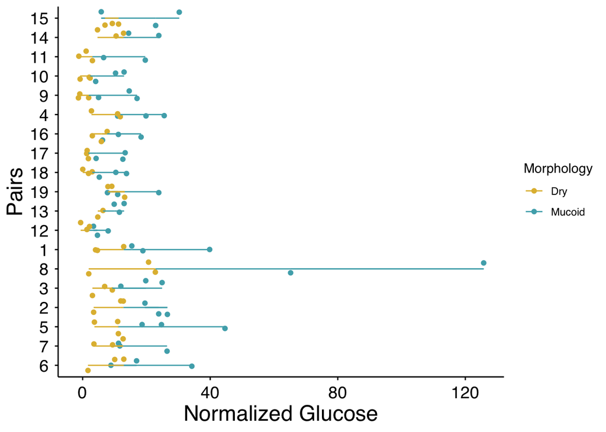

```r
Pair_Anthrone_complete$Pairs <- factor(Pair_Anthrone_complete$Pairs) #Make sure the Pairs are read as characters
#View(Pair_Anthrone_complete)

#View(Pair_Anthrone_complete)

Pairs_anthrone <- ggplot(Pair_Anthrone_complete, aes(x = Pairs, y = Glucose_OD600, color = Morphology)) +
  geom_jitter() +
  geom_line(aes(group = Pairs)) +
  scale_x_discrete(limits = unique(Pair_Anthrone_complete$Pairs)) +
  scale_color_manual(values = color_values) +
  theme_minimal() +
    labs(
    x = "Pairs",
    y = "Normalized Glucose") +
  coord_flip() +
    theme(
    text             = element_text(family = "Helvetica", color = "black"),
    axis.text        = element_text(size = 14, color = "black"),
    axis.title.x     = element_text(size = 18, color = "black"),
    axis.title.y     = element_text(size = 18, color = "black"),
    panel.grid.minor = element_blank(),
    panel.grid.major = element_blank(),
    axis.line        = element_line(color = "black"),
    axis.ticks       = element_line(color = "black")
    )


Pairs_anthrone
```

```r
ggsave(Pairs_anthrone, file = here("Phenotype", "Figures", "EPS_FigureS3A_FromR.pdf"), width = 10, height = 5, units = "in")

#### Anthrone per pair - Stats ####

Pair_Anthrone_mean <- left_join(Strain_used_pair, Anthrone_mean, by = "Strain")
Pair_Anthrone_mean
```

```
## # A tibble: 38 × 5
##    Strain_Code Strain Pairs Morphology Glucose_OD600_ave
##    <chr>       <chr>  <dbl> <chr>                  <dbl>
##  1 AVT3        003        6 Mucoid                 20.0
##  2 AVT4        004        7 Mucoid                 16.5
##  3 AVT12       012        5 Mucoid                 29.3
##  4 AVT15       015        2 Mucoid                 23.3
##  5 AVT16       016        3 Mucoid                 18.9
##  6 AVT18       018        8 Mucoid                 95.5
##  7 AVT29       029        1 Mucoid                 24.7
##  8 AVT41       041       12 Mucoid                  5.35
##  9 AVT49       049       13 Mucoid                 11.5
## 10 AVT62       062       19 Mucoid                 14.2
## # ℹ 28 more rows
```

```r
model1_raw <- lmerTest::lmer(Glucose_OD600_ave ~ Morphology + (1|Pairs), data = Pair_Anthrone_mean)

summary(model1_raw)
```

```
## Linear mixed model fit by REML. t-tests use Satterthwaite's method [
## lmerModLmerTest]
## Formula: Glucose_OD600_ave ~ Morphology + (1 | Pairs)
##    Data: Pair_Anthrone_mean
##
## REML criterion at convergence: 296
##
## Scaled residuals:
##     Min      1Q  Median      3Q     Max
## -0.8813 -0.3484 -0.0885  0.1455  4.8170
##
## Random effects:
##  Groups   Name        Variance Std.Dev.
##  Pairs    (Intercept)  55.27    7.434
##  Residual             138.01   11.748
## Number of obs: 38, groups:  Pairs, 19
##
## Fixed effects:
##                  Estimate Std. Error     df t value Pr(>|t|)
## (Intercept)         6.205      3.189 33.279   1.945  0.06022 .
## MorphologyMucoid   13.961      3.811 18.000   3.663  0.00178 **
## ---
## Signif. codes:  0 '***' 0.001 '**' 0.01 '*' 0.05 '.' 0.1 ' ' 1
##
## Correlation of Fixed Effects:
##             (Intr)
## MorphlgyMcd -0.598
```

```r
summary(model1_raw)$coefficients
```

```
##                   Estimate Std. Error       df  t value    Pr(>|t|)
## (Intercept)       6.204533   3.189385 33.27886 1.945369 0.060218488
## MorphologyMucoid 13.961156   3.811414 18.00000 3.662986 0.001779443
```

```r
### To create the table to export

### Fixed effect table
fixed_effects <- as.data.frame(summary(model1_raw)$coefficients) %>%
  rownames_to_column(var = "Term") %>%
  rename(t_value = `t value`, p_value = `Pr(>|t|)`) %>%
  mutate(
    across(c(Estimate, `Std. Error`, df, t_value), ~ sprintf("%.3f", .)),
    p_value = ifelse(as.numeric(p_value) < 0.001, "< 0.001", sprintf("%.3f", as.numeric(p_value)))
  )

### Random effect table

var_corr <- as.data.frame(VarCorr(model1_raw)) # var_corr has columns: grp, var1, vcov, sdcor
var_corr
```

```
##        grp        var1 var2      vcov     sdcor
## 1    Pairs (Intercept) <NA>  55.26608  7.434116
## 2 Residual        <NA> <NA> 138.00534 11.747567
```

```r
pairs_variance <- var_corr$vcov[var_corr$grp == "Pairs"]
pairs_variance
```

```
## [1] 55.26608
```

```r
pairs_sd <- var_corr$sdcor[var_corr$grp == "Pairs"]
pairs_sd
```

```
## [1] 7.434116
```

```r
residual_variance <- var_corr$vcov[var_corr$grp == "Residual"]
residual_variance
```

```
## [1] 138.0053
```

```r
# LRT for the random effect
lrt_result <- ranova(model1_raw)
lrt_result
```

```
## ANOVA-like table for random-effects: Single term deletions
##
## Model:
## Glucose_OD600_ave ~ Morphology + (1 | Pairs)
##             npar  logLik    AIC    LRT Df Pr(>Chisq)
## <none>         4 -148.01 304.02
## (1 | Pairs)    3 -148.78 303.56 1.5355  1     0.2153
```

```r
lrt_row <- lrt_result[rownames(lrt_result) != "<none>", ]
lrt_row
```

```
## ANOVA-like table for random-effects: Single term deletions
##
## Model:
## Glucose_OD600_ave ~ Morphology + (1 | Pairs)
##             npar  logLik    AIC    LRT Df Pr(>Chisq)
## (1 | Pairs)    3 -148.78 303.56 1.5355  1     0.2153
```

```r
#
icc_value <- icc(model1_raw)
icc_value
```

```
## # Intraclass Correlation Coefficient
##
##     Adjusted ICC: 0.286
##   Unadjusted ICC: 0.227
```

```r
### Combined the supplementary tables

random_effects_rows <- data.frame(
  Term = c("Random effect: Pairs (variance)",
           "Random effect: Pairs (LRT vs. no random effect)"),
  Estimate = c(sprintf("%.3f", pairs_variance), "-"),
  `Std. Error` = c("-", "-"),
  df = c("-", sprintf("%.0f", lrt_row$Df)),
  t_value = c("-", sprintf("%.3f (\u03c7\u00b2)", lrt_row$LRT)),
  p_value = c("-", ifelse(lrt_row$`Pr(>Chisq)` < 0.001, "< 0.001",
                           sprintf("%.3f", lrt_row$`Pr(>Chisq)`))),
  check.names = FALSE
)

full_table <- bind_rows(fixed_effects, random_effects_rows)
full_table
```

```
##                                              Term Estimate Std. Error     df
## 1                                     (Intercept)    6.205      3.189 33.279
## 2                                MorphologyMucoid   13.961      3.811 18.000
## 3                 Random effect: Pairs (variance)   55.266          -      -
## 4 Random effect: Pairs (LRT vs. no random effect)        -          -      1
##      t_value p_value
## 1      1.945   0.060
## 2      3.663   0.002
## 3          -       -
## 4 1.535 (χ²)   0.215
```

```r
write_xlsx(full_table, here("Phenotype", "Tables", "EPS_TableS3A_FromR.xlsx"))
```

#### Assess morphotype and normalized glucose

We will first determine the effect of morphotype and phylogenetic relatedness amount of EPS produced by each morphotype (mucoid and dry) in the whole collection, and whether morphotype or phylogenetic relatedness affects this trait

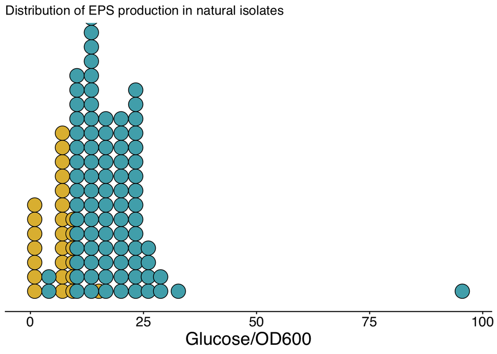

```r
Histo_balls <- ggplot(Anthrone_mean, aes(x = Glucose_OD600_ave)) +
  geom_dotplot(aes(fill = Morphology)) +
  labs(title = "Distribution of EPS production in natural isolates", x = "Glucose/OD600") +
  scale_fill_manual(values = color_values)+
  theme_classic() +
    theme(
    text             = element_text(family = "Helvetica", color = "black"),
    axis.text        = element_text(size = 14, color = "black"),
    axis.title.x     = element_text(size = 18, color = "black"),
    panel.grid       = element_blank(),
    axis.line        = element_line(color = "black"),
    axis.ticks       = element_line(color = "black"),
    axis.title.y     = element_blank(),
    axis.text.y      = element_blank(),
    axis.ticks.y     = element_blank(),
    axis.line.y      = element_blank(),
    legend.position  = "none")
Histo_balls
```

```r
ggsave(Histo_balls, file = here("Phenotype", "Figures", "EPS_FigureS3B_FromR.pdf"), width = 10, height = 10, units = "in")
#### Anthrone - whole collection - stats ####

aov2 <- aov(data = Anthrone_mean, Glucose_OD600_ave ~ Morphology)
aov2
```

```
## Call:
##    aov(formula = Glucose_OD600_ave ~ Morphology, data = Anthrone_mean)
##
## Terms:
##                 Morphology Residuals
## Sum of Squares    2618.549  9344.426
## Deg. of Freedom          1       113
##
## Residual standard error: 9.093626
## Estimated effects may be unbalanced
```

```r
anova2 <- anova(aov2)
anova2
```

```
## Analysis of Variance Table
##
## Response: Glucose_OD600_ave
##             Df Sum Sq Mean Sq F value    Pr(>F)
## Morphology   1 2618.5 2618.55  31.666 1.349e-07 ***
## Residuals  113 9344.4   82.69
## ---
## Signif. codes:  0 '***' 0.001 '**' 0.01 '*' 0.05 '.' 0.1 ' ' 1
```

```r
anova2 <- rownames_to_column(as.data.frame(anova2), var = "Term")

anova2_Table <- anova2 %>%
  mutate(across(where(is.numeric) & !matches("^Df$"), ~ sprintf("%.3f", .))) %>%
  mutate(`Pr(>F)` = ifelse(as.numeric(`Pr(>F)`) < 0.001, "< 0.001", `Pr(>F)`)) %>%
  dplyr::select(-`Mean Sq`)
anova2_Table
```

```
##         Term  Df   Sum Sq F value  Pr(>F)
## 1 Morphology   1 2618.549  31.666 < 0.001
## 2  Residuals 113 9344.426      NA    <NA>
```

```r
write_xlsx(anova2_Table, here("Phenotype", "Tables", "EPS_TableS3B_FromR.xlsx"))
```

### Morphotype and normalized glucose and phylogenetically relatedness

We will first determine if there is an effect of phylogenetic relatedness in the morphotype

```r
Strain_morphotype <- read_csv(here("Phenotype", "Tables", "PCA_scores_strains.csv"))
Strain_morphotype
```

```
## # A tibble: 117 × 121
##    Strain_Code Strain Morphology Pairs   PC1    PC2    PC3    PC4     PC5
##    <chr>       <chr>  <chr>      <dbl> <dbl>  <dbl>  <dbl>  <dbl>   <dbl>
##  1 AVT1        001    Mucoid        NA -69.6 -31.0   23.7  -14.8    0.245
##  2 AVT10       010    Mucoid        NA -69.7 -31.0   23.6  -14.8    0.490
##  3 AVT100      100    Dry            3 -43.7  -8.72 -25.3   61.6  -23.6
##  4 AVT101      101    Dry            4  13.1  -6.09 -14.4   16.6   33.3
##  5 AVT102      102    Dry            5 -34.7  -8.95 -11.9   21.4   14.7
##  6 AVT103      103    Dry            6 -69.8 -31.0   23.5  -14.6    0.408
##  7 AVT104      104    Dry            7  54.3  -1.47   3.56  -3.19  -0.805
##  8 AVT105      105    Dry            8 -60.9 201.   104.    35.7   22.5
##  9 AVT106      106    Dry            9 -28.4  61.5   -6.94 -22.3  -59.2
## 10 AVT107      107    Dry           10  54.0  -1.52   3.43  -3.11  -0.767
## # ℹ 107 more rows
## # ℹ 112 more variables: PC6 <dbl>, PC7 <dbl>, PC8 <dbl>, PC9 <dbl>, PC10 <dbl>,
## #   PC11 <dbl>, PC12 <dbl>, PC13 <dbl>, PC14 <dbl>, PC15 <dbl>, PC16 <dbl>,
## #   PC17 <dbl>, PC18 <dbl>, PC19 <dbl>, PC20 <dbl>, PC21 <dbl>, PC22 <dbl>,
## #   PC23 <dbl>, PC24 <dbl>, PC25 <dbl>, PC26 <dbl>, PC27 <dbl>, PC28 <dbl>,
## #   PC29 <dbl>, PC30 <dbl>, PC31 <dbl>, PC32 <dbl>, PC33 <dbl>, PC34 <dbl>,
## #   PC35 <dbl>, PC36 <dbl>, PC37 <dbl>, PC38 <dbl>, PC39 <dbl>, PC40 <dbl>, …
```

```r
### Morphotype ###

## I will use 1 for Mucoid and 0 for Dry

Strain_morphotype <- Strain_morphotype %>%
  mutate(Morphology_binary = if_else(Morphology == "Mucoid", 1, 0))


model <- glm(Morphology_binary ~ PC1 + PC2, data = Strain_morphotype, family = "binomial")
summary(model)
```

```
##
## Call:
## glm(formula = Morphology_binary ~ PC1 + PC2, family = "binomial",
##     data = Strain_morphotype)
##
## Coefficients:
##              Estimate Std. Error z value Pr(>|z|)
## (Intercept)  1.253668   0.228961   5.475 4.36e-08 ***
## PC1          0.007647   0.004290   1.782   0.0747 .
## PC2         -0.005110   0.005612  -0.911   0.3625
## ---
## Signif. codes:  0 '***' 0.001 '**' 0.01 '*' 0.05 '.' 0.1 ' ' 1
##
## (Dispersion parameter for binomial family taken to be 1)
##
##     Null deviance: 126.41  on 116  degrees of freedom
## Residual deviance: 122.23  on 114  degrees of freedom
## AIC: 128.23
##
## Number of Fisher Scoring iterations: 4
```

```r
#exp(coef(model))       # odds ratios — much more interpretable than log-odds
#exp(confint(model))    # 95% CI on the odds ratios


anova <- Anova(model, type = "II", test.statistic = "LR")
anova
```

```
## Analysis of Deviance Table (Type II tests)
##
## Response: Morphology_binary
##     LR Chisq Df Pr(>Chisq)
## PC1   3.2682  1    0.07064 .
## PC2   0.8263  1    0.36335
## ---
## Signif. codes:  0 '***' 0.001 '**' 0.01 '*' 0.05 '.' 0.1 ' ' 1
```

```r
anova <- rownames_to_column(as.data.frame(anova), var = "Term")
anova
```

```
##   Term  LR Chisq Df Pr(>Chisq)
## 1  PC1 3.2681750  1 0.07063616
## 2  PC2 0.8262698  1 0.36335337
```

```r
anova <- anova %>%
  mutate(across(where(is.numeric) & !matches("^Df$"), ~ sprintf("%.3f", .))) %>%
  mutate(`Pr(>Chisq)` = ifelse(as.numeric(`Pr(>Chisq)`) < 0.001, "< 0.001", `Pr(>Chisq)`))

write_xlsx(anova, here("Phenotype", "Tables", "EPS_TableS5A_FromR.xlsx"))


### Normalized Glucose ###


Anthrone_mean <- read_csv(here("Phenotype", "Tables", "Anthrone_mean.csv"))
Anthrone_mean
```

```
## # A tibble: 115 × 3
##    Strain Morphology Glucose_OD600_ave
##    <chr>  <chr>                  <dbl>
##  1 001    Mucoid                  22.6
##  2 002    Mucoid                  23.6
##  3 003    Mucoid                  20.0
##  4 004    Mucoid                  16.5
##  5 005    Mucoid                  17.4
##  6 006    Mucoid                  23.9
##  7 007    Mucoid                  26.0
##  8 008    Mucoid                  23.6
##  9 009    Mucoid                  18.5
## 10 010    Mucoid                  24.0
## # ℹ 105 more rows
```

```r
Anthrone_phylo_ave <- merge(Anthrone_mean %>% dplyr::select(-"Morphology"), Strain_morphotype, by = "Strain")
Anthrone_phylo_ave
```

```
##     Strain Glucose_OD600_ave Strain_Code Morphology Pairs        PC1
## 1      001        22.5604561        AVT1     Mucoid    NA -69.572604
## 2      002        23.5777361        AVT2     Mucoid    NA  53.953350
## 3      003        20.0124334        AVT3     Mucoid     6  53.446160
## 4      004        16.4625525        AVT4     Mucoid     7  53.870705
## 5      005        17.3644828        AVT5     Mucoid    NA -13.391227
## 6      006        23.9252430        AVT6     Mucoid    NA -69.769009
## 7      007        25.9929970        AVT7     Mucoid    NA -69.569352
## 8      008        23.6203679        AVT8     Mucoid    NA  53.152345
## 9      009        18.5455882        AVT9     Mucoid    NA  53.895904
## 10     010        24.0464515       AVT10     Mucoid    NA -69.666095
## 11     011        17.4651011       AVT11     Mucoid    NA  54.040287
## 12     012        29.3321062       AVT12     Mucoid     5 -34.618983
## 13     013        28.2392040       AVT13     Mucoid    NA  53.400697
## 14     014        22.7421248       AVT14     Mucoid    NA -58.098313
```

[output cut: 2885 more lines]

```r
model <- lm(Glucose_OD600_ave ~ PC1 + PC2, data = Anthrone_phylo_ave)
summary(model)
```

```
##
## Call:
## lm(formula = Glucose_OD600_ave ~ PC1 + PC2, data = Anthrone_phylo_ave)
##
## Residuals:
##     Min      1Q  Median      3Q     Max
## -22.119  -6.114  -0.889   5.376  59.462
##
## Coefficients:
##             Estimate Std. Error t value Pr(>|t|)
## (Intercept) 15.24556    0.89293  17.074  < 2e-16 ***
## PC1         -0.04241    0.01681  -2.523  0.01303 *
## PC2          0.09035    0.02601   3.474  0.00073 ***
## ---
## Signif. codes:  0 '***' 0.001 '**' 0.01 '*' 0.05 '.' 0.1 ' ' 1
##
## Residual standard error: 9.575 on 112 degrees of freedom
## Multiple R-squared:  0.1417, Adjusted R-squared:  0.1264
## F-statistic: 9.248 on 2 and 112 DF,  p-value: 0.0001917
```

```r
anova <- anova(model)
anova
```

```
## Analysis of Variance Table
##
## Response: Glucose_OD600_ave
##            Df  Sum Sq Mean Sq F value  Pr(>F)
## PC1         1   589.2  589.21  6.4273 0.01262 *
## PC2         1  1106.4 1106.40 12.0690 0.00073 ***
## Residuals 112 10267.4   91.67
## ---
## Signif. codes:  0 '***' 0.001 '**' 0.01 '*' 0.05 '.' 0.1 ' ' 1
```

```r
anova <- rownames_to_column(as.data.frame(anova), var = "Term")
anova
```

```
##        Term  Df     Sum Sq    Mean Sq   F value       Pr(>F)
## 1       PC1   1   589.2097  589.20974  6.427307 0.0126176529
## 2       PC2   1  1106.4035 1106.40351 12.069039 0.0007299545
## 3 Residuals 112 10267.3622   91.67288        NA           NA
```

```r
#This model is asking whether the strain's position among the major axes of genome-wide relatedness is predicting whether is Mucoid and Dry

anova <- anova %>%
  mutate(across(where(is.numeric) & !matches("^Df$"), ~ sprintf("%.3f", .))) %>%
  mutate(`Pr(>F)` = ifelse(as.numeric(`Pr(>F)`) < 0.001, "< 0.001", `Pr(>F)`)) %>%
  dplyr::select(-`Mean Sq`)
anova
```

```
##        Term  Df    Sum Sq F value Pr(>F)
## 1       PC1   1   589.210   6.427  0.013
## 2       PC2   1  1106.404  12.069  0.001
## 3 Residuals 112 10267.362      NA   <NA>
```

```r
write_xlsx(anova, here("Phenotype", "Tables", "EPS_TableS5B_FromR.xlsx"))
```

### SOIL

Open files

```r
soil_data <- read_excel(here("Phenotype", "Data_input", "Soil_Survival&Growth.xlsx"))

#View(soil_data)
#View(soil_data)
soil_data <- soil_data %>% filter(Rep_tube != "s") #Filtering out the "sacrificed" plants


soil_data$Colonies_Dry <- as.numeric(soil_data$Colonies_Dry)
soil_data$Colonies_Mucoid <- as.numeric(soil_data$Colonies_Mucoid)
soil_data$Dilution <- as.numeric(soil_data$Dilution)
soil_data$Volume_ul <- as.numeric(soil_data$Volume_ul)
```

```r
soil_data <- soil_data %>% filter(!is.na(Volume_ul)) #Filtering out the ones that were not assessed
#View(soil_data)

## Calculate CFUs

soil_data <- soil_data %>%
  mutate(
    Dry_CFU_Total = Colonies_Dry*10^5*10^(Dilution -1)/Volume_ul,
    Mucoid_CFU_Total = Colonies_Mucoid*10^5*10^(Dilution -1)/Volume_ul,
    Total_CFU = Dry_CFU_Total + Mucoid_CFU_Total,
    Percentage_Dry = Colonies_Dry*100/(Colonies_Dry + Colonies_Mucoid)
  )

### Remove the ones that had a Total_CFU of 0

soil_data <- soil_data %>% filter((Colonies_Dry + Colonies_Mucoid) != "0")

#View(soil_data)


## I will give different shapes to timepoints and colors to treatments.

mycols<-data.frame(Treatment=c("22 °C", "32 °C","4 °C", "Drought"), cols=c("#999999","#D55E00", "#882255", "#56B4E9"))
mycols$Treatment <- factor(mycols$Treatment, ordered=TRUE)
mycols <- setNames(mycols$cols, mycols$Treatment)

## For survival

myshapes_survival<-data.frame(Timepoint=c("3 months","6 months","12 months"),shapes=c(16, 5, 12))
myshapes_survival$Timepoint <- factor(myshapes_survival$Timepoint, ordered = TRUE)
myshapes_survival <- setNames(myshapes_survival$shapes, myshapes_survival$Timepoint)

## For growth

myshapes_growth<-data.frame(Timepoint= c("7 days", "14 days", "21 days", "42 days"),shapes=c(1, 2, 3, 4))
myshapes_growth$Timepoint <- factor(myshapes_growth$Timepoint, ordered = TRUE)
myshapes_growth <- setNames(myshapes_growth$shapes, myshapes_growth$Timepoint)


#### Expand the "initial" values to the treatments ####

# I measured the initial values from the tubes inoculated with the Mucoid, Dry and Mixed population. The values were different between Growth and Survival, therefore I will divide them in two.

### For survival

soil_survival <- soil_data %>% filter(Condition == "Survival")


expand_survival_baseline <- function(data, morphology_value) {

  dat_morph <- data %>%
    filter(Population_Morphology == morphology_value)

  dat_no_initial <- dat_morph %>%
    filter(Timepoint != "0")

  initial_baseline <- dat_morph %>%
    filter(Timepoint == "0")

  treatments_to_add <- dat_no_initial %>%
    distinct(Treatment) %>%
    pull(Treatment) %>%
    unique()

  baseline_rows <- purrr::map_dfr(
    treatments_to_add,
    ~ initial_baseline %>%
      mutate(Treatment = .x, Timepoint = "0")
  )

  expanded <- bind_rows(baseline_rows, dat_no_initial) %>%
    mutate(Log10Total = log10(Total_CFU))

  return(expanded)
}


soil_survival
```

```
## # A tibble: 430 × 15
##    Name     Treatment Population_Morphology Rep_tube Rep_dot Timepoint Volume_ul
##    <chr>    <chr>     <chr>                 <chr>      <dbl> <chr>         <dbl>
##  1 4 °C_Mu… 4 °C      Mucoid                a              1 3 months         40
##  2 4 °C_Mu… 4 °C      Mucoid                a              2 3 months         40
##  3 4 °C_Mu… 4 °C      Mucoid                b              1 3 months         40
##  4 4 °C_Mu… 4 °C      Mucoid                b              2 3 months         40
##  5 4 °C_Mu… 4 °C      Mucoid                c              1 3 months         40
##  6 4 °C_Mu… 4 °C      Mucoid                c              2 3 months         40
##  7 4 °C_Mu… 4 °C      Mucoid                d              1 3 months         40
##  8 4 °C_Mu… 4 °C      Mucoid                d              2 3 months         40
##  9 4 °C_Mu… 4 °C      Mucoid                e              1 3 months         40
## 10 4 °C_Mu… 4 °C      Mucoid                e              2 3 months         40
## # ℹ 420 more rows
## # ℹ 8 more variables: Dilution <dbl>, Colonies_Mucoid <dbl>,
## #   Colonies_Dry <dbl>, Condition <chr>, Dry_CFU_Total <dbl>,
## #   Mucoid_CFU_Total <dbl>, Total_CFU <dbl>, Percentage_Dry <dbl>
```

```r
Survival_Mesocoms_Mucoid.expanded  <- expand_survival_baseline(soil_survival, "Mucoid")
Survival_Mesocoms_Dry.expanded     <- expand_survival_baseline(soil_survival, "Dry")
Survival_Mesocoms_Mixture.expanded <- expand_survival_baseline(soil_survival, "Mixture")

### Merge all the files Survival

Survival_Mesocosm.expanded <- rbind(Survival_Mesocoms_Mucoid.expanded, Survival_Mesocoms_Dry.expanded, Survival_Mesocoms_Mixture.expanded)


#View(Survival_Mesocoms_Mucoid.expanded) Looks correct

### For growth

soil_growth <- soil_data %>% filter(Condition == "Growth")


expand_growth_baseline <- function(data, morphology_value) {

  dat_morph <- data %>%
    filter(Population_Morphology == morphology_value)

  dat_no_initial <- dat_morph %>%
    filter(Timepoint != "0")

  initial_baseline <- dat_morph %>%
    filter(Timepoint == "0")

  treatments_to_add <- dat_no_initial %>%
    distinct(Treatment) %>%
    pull(Treatment) %>%
    unique()

  baseline_rows <- purrr::map_dfr(
    treatments_to_add,
    ~ initial_baseline %>%
      mutate(Treatment = .x, Timepoint = "0")
  )

  expanded <- bind_rows(baseline_rows, dat_no_initial) %>%
    mutate(Log10Total = log10(Total_CFU))

  return(expanded)
}


Growth_Mesocoms_Mucoid.expanded  <- expand_growth_baseline(soil_growth, "Mucoid")
Growth_Mesocoms_Dry.expanded     <- expand_growth_baseline(soil_growth, "Dry")
Growth_Mesocoms_Mixture.expanded <- expand_growth_baseline(soil_growth, "Mixture")

## Merge all the files for Growth:

Growth_Mesocosm.expanded <- rbind(Growth_Mesocoms_Mucoid.expanded, Growth_Mesocoms_Dry.expanded, Growth_Mesocoms_Mixture.expanded)

## Now merge survival and growth

soil.expanded <- rbind(Growth_Mesocosm.expanded, Survival_Mesocosm.expanded)
#View(soil.expanded)



### Now calculate the average of the expanded data ###


soil.expanded_ave <- soil.expanded %>% ## Calculating the averages
  group_by(Name, Treatment, Population_Morphology, Timepoint, Rep_tube, Condition) %>%
  summarise(
    Dry_CFU_Total_ave   = mean(Dry_CFU_Total,   na.rm = TRUE),
    Mucoid_CFU_Total_ave = mean(Mucoid_CFU_Total, na.rm = TRUE),
    Total_CFU_ave       = mean(Total_CFU,       na.rm = TRUE),
    Percentage_Dry_ave  = mean(Percentage_Dry,  na.rm = TRUE),
    Log10Total_ave = mean(Log10Total, na.rm = TRUE),
    .groups = "drop"
  )
#View(soil.expanded_ave)

### I will construct the files for the population size analysis using the soil.expanded_ave values so I work with the means ###

growth_levels   <- c("0", "7 days", "14 days", "21 days", "42 days")
survival_levels <- c("0", "3 months", "6 months", "12 months")

popsize_tube <- soil.expanded_ave %>%
  group_by(Condition, Timepoint, Treatment, Population_Morphology) %>%
  summarise(median  = median(Log10Total_ave),
            min     = min(Log10Total_ave),
            max     = max(Log10Total_ave),
            n_tubes = n(),
            .groups = "drop") %>%
  mutate(Timepoint = factor(Timepoint, levels = unique(c(survival_levels, growth_levels))))
```

#### Mixture

##### Mixture - Growth

###### Population size

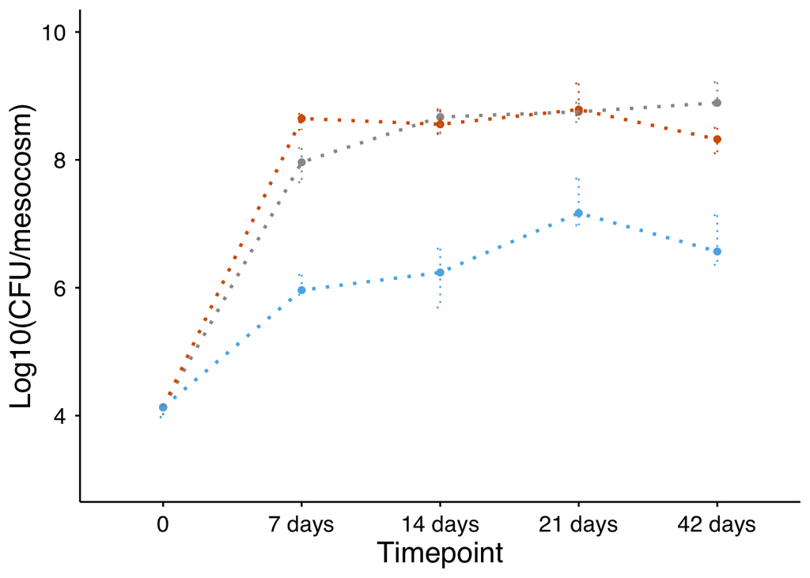

```r
### Figure 3 A ###

Growth_Mixture <- ggplot(popsize_tube %>% filter(Condition == "Growth", Population_Morphology == "Mixture"),
       aes(x = Timepoint, y = median,
           color = Treatment,
           linetype = Population_Morphology,
           group = interaction(Treatment, Population_Morphology))) +
  geom_point() +
  geom_line(size = 1) +
  geom_errorbar(aes(ymin = min, ymax = max), width = 0.05) +
  scale_color_manual(values = mycols) +
  scale_linetype_manual(values = c("Mixture" = "dotted")) +
  xlab("Timepoint") +
  ylab("Log10(CFU/mesocosm)") +
#  scale_y_log10() +
    coord_cartesian(ylim = c(3, 10)) +
#  facet_wrap(~Condition,  scales = "free_x") +
  theme_minimal(base_size = 12) +
  theme(
    text = element_text(family = "Helvetica", color = "black"),
    axis.text = element_text(size = 14, color = "black"),
    axis.title.x = element_text(size = 18),
    axis.title.y = element_text(size = 18),
    panel.grid = element_blank(),
    axis.line = element_line(color = "black"),
    axis.ticks = element_line(color = "black"),
    legend.position = "none"
  )
Growth_Mixture
```

```r
ggsave(Growth_Mixture,
       filename = here("Phenotype", "Figures" ,"EPS_Figure3A_FromR.pdf"),
       device = "pdf",
       height = 4, width = 5, units = "in")
```

###### Percentage of Dry bacteria– Growth

```r
Growth_Mesocosm_Mixture_initial_ave <- soil.expanded_ave %>% filter(Condition == "Growth" & Population_Morphology == "Mixture" & Timepoint == "0")

Initial_ave_growth <- Growth_Mesocosm_Mixture_initial_ave %>%
  ungroup() %>%
  summarise(Initial_ave_growth = mean(Percentage_Dry_ave, na.rm = TRUE)) %>%
  pull(Initial_ave_growth)

Initial_ave_growth
```

```
## [1] 55.49316
```

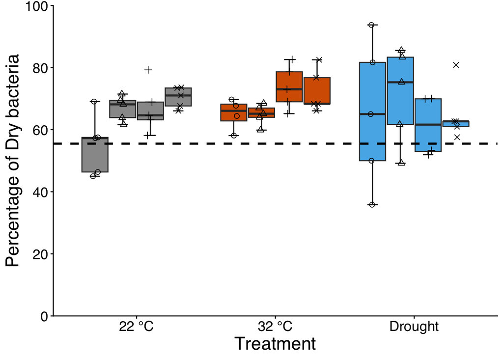

```r
Growth_DryPercentage <- ggplot(data = soil.expanded_ave %>%
                                filter(Condition == "Growth" & Population_Morphology == "Mixture" & Timepoint != "0") %>%
                                mutate(Timepoint = factor(Timepoint, levels = c("7 days", "14 days", "21 days", "42 days"))),
                                aes(x = Treatment, y = Percentage_Dry_ave, fill = Treatment, group = interaction(Treatment, Timepoint))) +
      stat_boxplot(geom = "errorbar", width = 0.3, color = "black", position = position_dodge(width = 0.8)) +
  geom_boxplot(outlier.shape = NA, position = position_dodge(width = 0.8)) +
  geom_jitter(aes(shape = Timepoint), position = position_jitterdodge(jitter.width = 0.15, dodge.width = 0.8), size = 2, color = "black") +
  scale_shape_manual(values = myshapes_growth) +
  scale_fill_manual(values = mycols) +
  scale_y_continuous(limits = c(0, 100), breaks = seq(0, 100, 20), expand = c(0, 0)) +
  geom_hline(yintercept= Initial_ave_growth, linetype="dashed", color="black", size=1) +
  labs(x = "Treatment", y = "Percentage of Dry bacteria") +
  theme_classic() +
  theme(
    text = element_text(family = "Helvetica", color = "black"),
    axis.text = element_text(size = 14, color = "black"),
    axis.title.x = element_text(size = 18),
    axis.title.y = element_text(size = 18),
    panel.grid = element_blank(),
    axis.line = element_line(color = "black"),
    axis.ticks = element_line(color = "black"),
    legend.position = "none")

Growth_DryPercentage
```

```r
ggsave(Growth_DryPercentage,
       filename = here("Phenotype", "Figures","EPS_Figure3C_FromR.pdf"),
       device = "pdf",
       height = 4, width = 5, units = "in")

soil.expanded_ave %>% filter(Condition == "Growth" & Population_Morphology == "Mixture" & Timepoint != "0")
```

```
## # A tibble: 58 × 11
##    Name            Treatment Population_Morphology Timepoint Rep_tube Condition
##    <chr>           <chr>     <chr>                 <chr>     <chr>    <chr>
##  1 22 °C_Mixture_a 22 °C     Mixture               14 days   a        Growth
##  2 22 °C_Mixture_a 22 °C     Mixture               21 days   a        Growth
##  3 22 °C_Mixture_a 22 °C     Mixture               42 days   a        Growth
##  4 22 °C_Mixture_a 22 °C     Mixture               7 days    a        Growth
##  5 22 °C_Mixture_b 22 °C     Mixture               14 days   b        Growth
##  6 22 °C_Mixture_b 22 °C     Mixture               21 days   b        Growth
##  7 22 °C_Mixture_b 22 °C     Mixture               42 days   b        Growth
##  8 22 °C_Mixture_b 22 °C     Mixture               7 days    b        Growth
##  9 22 °C_Mixture_c 22 °C     Mixture               14 days   c        Growth
## 10 22 °C_Mixture_c 22 °C     Mixture               21 days   c        Growth
## # ℹ 48 more rows
## # ℹ 5 more variables: Dry_CFU_Total_ave <dbl>, Mucoid_CFU_Total_ave <dbl>,
## #   Total_CFU_ave <dbl>, Percentage_Dry_ave <dbl>, Log10Total_ave <dbl>
```

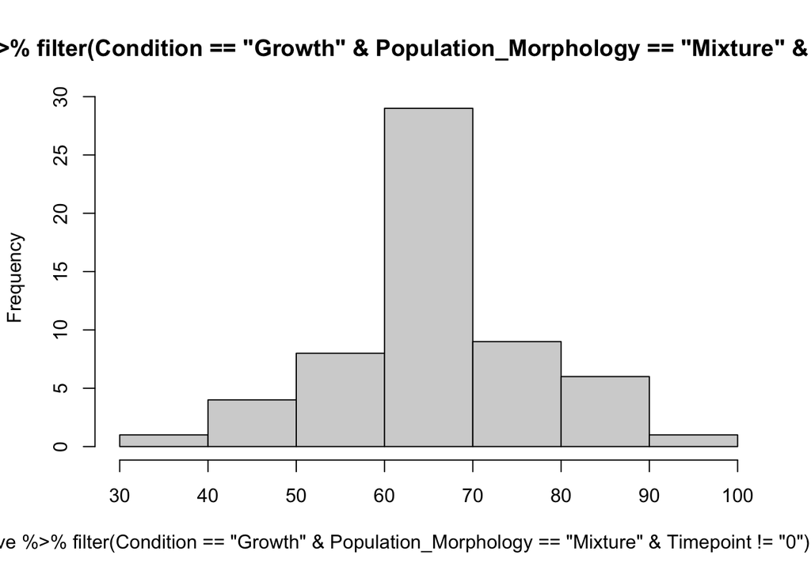

```r
hist((soil.expanded_ave %>% filter(Condition == "Growth" & Population_Morphology == "Mixture" & Timepoint != "0"))$Percentage_Dry_ave) #Normally distributed.
```

```r
### Statistics

aov_Mixed_PercDry_Growth <- aov(Percentage_Dry_ave ~ Treatment*Timepoint, soil.expanded_ave %>%
                                filter(Condition == "Growth" & Population_Morphology == "Mixture")) ## In the ANOVA I am taking into account the timepoint 0
anova_Mixed_PercDry_Growth <- anova(aov_Mixed_PercDry_Growth) #Calculate the anova

anova_Mixed_PercDry_Growth <- rownames_to_column(as.data.frame(anova_Mixed_PercDry_Growth), var = "Term") #For table formating
anova_Mixed_PercDry_Growth
```

```
##                  Term Df    Sum Sq   Mean Sq   F value      Pr(>F)
## 1           Treatment  2  164.0885  82.04425 0.8495307 0.433149232
## 2           Timepoint  4 1699.6900 424.92250 4.3998782 0.003705917
## 3 Treatment:Timepoint  8  770.4379  96.30474 0.9971915 0.448718648
## 4           Residuals 55 5311.6783  96.57597        NA          NA
```

```r
## Aesthetics

anova_Mixed_PercDry_Growth <- anova_Mixed_PercDry_Growth %>%
  mutate(across(where(is.numeric) & !matches("^Df$"), ~ sprintf("%.3f", .))) %>%
  mutate(`Pr(>F)` = ifelse(as.numeric(`Pr(>F)`) < 0.001, "< 0.001", `Pr(>F)`)) %>%
  dplyr::select(-`Mean Sq`)
anova_Mixed_PercDry_Growth
```

```
##                  Term Df   Sum Sq F value Pr(>F)
## 1           Treatment  2  164.089   0.850  0.433
## 2           Timepoint  4 1699.690   4.400  0.004
## 3 Treatment:Timepoint  8  770.438   0.997  0.449
## 4           Residuals 55 5311.678      NA   <NA>
```

```r
write_xlsx(anova_Mixed_PercDry_Growth, here("Phenotype", "Tables", "EPS_TableS7A_FromR.xlsx"))


## I will subset the each treatment and see what timepoints statistically have higher percentage of dry bacteria

### 32 C ###
Growth_32 <- soil.expanded_ave %>%filter(Condition == "Growth" & Population_Morphology == "Mixture", Treatment == "32 °C")
aov_Mixed_PercDry_Growth_32C <- aov(Percentage_Dry_ave ~ Timepoint, Growth_32)
summary(aov_Mixed_PercDry_Growth_32C)
```

```
##             Df Sum Sq Mean Sq F value  Pr(>F)
## Timepoint    4  935.5  233.88   6.885 0.00152 **
## Residuals   18  611.4   33.97
## ---
## Signif. codes:  0 '***' 0.001 '**' 0.01 '*' 0.05 '.' 0.1 ' ' 1
```

```r
anova_Mixed_PercDry_Growth_32C <- anova(aov_Mixed_PercDry_Growth_32C)

anova_Mixed_PercDry_Growth_32C <- rownames_to_column(as.data.frame(anova_Mixed_PercDry_Growth_32C), var = "Term")
anova_Mixed_PercDry_Growth_32C <- anova_Mixed_PercDry_Growth_32C %>% mutate(Treatment = "32 °C")


### Dunnett test

Growth_32$Timepoint <- relevel(factor(Growth_32$Timepoint), ref = "0")

aov_Mixed_PercDry_Growth_32C <- aov(Percentage_Dry_ave ~ Timepoint, Growth_32)

dunnett_Mixed_PercDry_Growth_32C <- glht(aov_Mixed_PercDry_Growth_32C, linfct = mcp(Timepoint = "Dunnett"))
summary(dunnett_Mixed_PercDry_Growth_32C)
```

```
##
##   Simultaneous Tests for General Linear Hypotheses
##
## Multiple Comparisons of Means: Dunnett Contrasts
##
##
## Fit: aov(formula = Percentage_Dry_ave ~ Timepoint, data = Growth_32)
##
## Linear Hypotheses:
##                  Estimate Std. Error t value Pr(>|t|)
## 14 days - 0 == 0    9.380      3.910   2.399   0.0835 .
## 21 days - 0 == 0   18.179      3.910   4.650   <0.001 ***
## 42 days - 0 == 0   16.896      3.910   4.322   0.0013 **
## 7 days - 0 == 0     9.487      4.121   2.302   0.1006
## ---
## Signif. codes:  0 '***' 0.001 '**' 0.01 '*' 0.05 '.' 0.1 ' ' 1
## (Adjusted p values reported -- single-step method)
```

```r
dunnett_summary <- summary(dunnett_Mixed_PercDry_Growth_32C)

Dunnett_Mixed_PercDry_Growth_32C <- data.frame(
  Treatment = "32 °C",
  Comparison = names(dunnett_summary$test$coefficients),
  diff = sprintf("%.3f", dunnett_summary$test$coefficients),
  P = ifelse(dunnett_summary$test$pvalues < 0.001, "< 0.001",
             sprintf("%.3f", dunnett_summary$test$pvalues))
)

Dunnett_Mixed_PercDry_Growth_32C
```

```
##   Treatment  Comparison   diff       P
## 1     32 °C 14 days - 0  9.380   0.084
## 2     32 °C 21 days - 0 18.179 < 0.001
## 3     32 °C 42 days - 0 16.896   0.001
## 4     32 °C  7 days - 0  9.487   0.101
```

```r
### 22 C ###


Growth_22 <- soil.expanded_ave %>%filter(Condition == "Growth" & Population_Morphology == "Mixture", Treatment == "22 °C")
aov_Mixed_PercDry_Growth_22C <- aov(Percentage_Dry_ave ~ Timepoint, Growth_22)
summary(aov_Mixed_PercDry_Growth_22C)
```

```
##             Df Sum Sq Mean Sq F value  Pr(>F)
## Timepoint    4  959.6  239.91   5.395 0.00448 **
## Residuals   19  844.9   44.47
## ---
## Signif. codes:  0 '***' 0.001 '**' 0.01 '*' 0.05 '.' 0.1 ' ' 1
```

```r
anova_Mixed_PercDry_Growth_22C <- anova(aov_Mixed_PercDry_Growth_22C)

anova_Mixed_PercDry_Growth_22C <- rownames_to_column(as.data.frame(anova_Mixed_PercDry_Growth_22C), var = "Term")
anova_Mixed_PercDry_Growth_22C <- anova_Mixed_PercDry_Growth_22C %>% mutate(Treatment = "22 °C")
anova_Mixed_PercDry_Growth_22C
```

```
##        Term Df   Sum Sq   Mean Sq  F value     Pr(>F) Treatment
## 1 Timepoint  4 959.6242 239.90604 5.394712 0.00447921     22 °C
## 2 Residuals 19 844.9412  44.47059       NA         NA     22 °C
```

```r
### Dunnett test

Growth_22$Timepoint <- relevel(factor(Growth_22$Timepoint), ref = "0")

aov_Mixed_PercDry_Growth_22C <- aov(Percentage_Dry_ave ~ Timepoint, Growth_22)

dunnett_Mixed_PercDry_Growth_22C <- glht(aov_Mixed_PercDry_Growth_22C, linfct = mcp(Timepoint = "Dunnett"))
summary(dunnett_Mixed_PercDry_Growth_22C)
```

```
##
##   Simultaneous Tests for General Linear Hypotheses
##
## Multiple Comparisons of Means: Dunnett Contrasts
##
##
## Fit: aov(formula = Percentage_Dry_ave ~ Timepoint, data = Growth_22)
##
## Linear Hypotheses:
##                  Estimate Std. Error t value Pr(>|t|)
## 14 days - 0 == 0  11.3959     4.4735   2.547   0.0606 .
## 21 days - 0 == 0  11.3209     4.4735   2.531   0.0626 .
## 42 days - 0 == 0  14.8564     4.4735   3.321   0.0122 *
## 7 days - 0 == 0   -0.4556     4.4735  -0.102   0.9999
## ---
## Signif. codes:  0 '***' 0.001 '**' 0.01 '*' 0.05 '.' 0.1 ' ' 1
## (Adjusted p values reported -- single-step method)
```

```r
dunnett_summary <- summary(dunnett_Mixed_PercDry_Growth_22C)

Dunnett_Mixed_PercDry_Growth_22C <- data.frame(
  Treatment = "22 °C",
  Comparison = names(dunnett_summary$test$coefficients),
  diff = sprintf("%.3f", dunnett_summary$test$coefficients),
  P = ifelse(dunnett_summary$test$pvalues < 0.001, "< 0.001",
             sprintf("%.3f", dunnett_summary$test$pvalues))
)

Dunnett_Mixed_PercDry_Growth_22C
```

```
##   Treatment  Comparison   diff     P
## 1     22 °C 14 days - 0 11.396 0.061
## 2     22 °C 21 days - 0 11.321 0.063
## 3     22 °C 42 days - 0 14.856 0.012
## 4     22 °C  7 days - 0 -0.456 1.000
```

```r
### Drought ###

Growth_drought <- soil.expanded_ave %>% filter(Condition == "Growth" & Population_Morphology == "Mixture", Treatment == "Drought")

aov_Mixed_PercDry_Growth_DroughtC <- aov(Percentage_Dry_ave ~ Timepoint, Growth_drought)
summary(aov_Mixed_PercDry_Growth_DroughtC)
```

```
##             Df Sum Sq Mean Sq F value Pr(>F)
## Timepoint    4    575   143.8   0.671   0.62
## Residuals   18   3855   214.2
```

```r
anova_Mixed_PercDry_Growth_DroughtC <- anova(aov_Mixed_PercDry_Growth_DroughtC)

anova_Mixed_PercDry_Growth_DroughtC <- rownames_to_column(as.data.frame(anova_Mixed_PercDry_Growth_DroughtC), var = "Term")
anova_Mixed_PercDry_Growth_DroughtC
```

```
##        Term Df    Sum Sq  Mean Sq   F value    Pr(>F)
## 1 Timepoint  4  575.0018 143.7504 0.6711509 0.6204469
## 2 Residuals 18 3855.3300 214.1850        NA        NA
```

```r
anova_Mixed_PercDry_Growth_DroughtC <- anova_Mixed_PercDry_Growth_DroughtC %>% mutate(Treatment = "Drought")

### Dunnett test

Growth_drought$Timepoint <- relevel(factor(Growth_drought$Timepoint), ref = "0")

aov_Mixed_PercDry_Growth_DroughtC <- aov(Percentage_Dry_ave ~ Timepoint, Growth_drought)

dunnett_Mixed_PercDry_Growth_drought <- glht(aov_Mixed_PercDry_Growth_DroughtC, linfct = mcp(Timepoint = "Dunnett"))
summary(dunnett_Mixed_PercDry_Growth_drought)
```

```
##
##   Simultaneous Tests for General Linear Hypotheses
##
## Multiple Comparisons of Means: Dunnett Contrasts
##
##
## Fit: aov(formula = Percentage_Dry_ave ~ Timepoint, data = Growth_drought)
##
## Linear Hypotheses:
##                  Estimate Std. Error t value Pr(>|t|)
## 14 days - 0 == 0   15.492      9.817   1.578    0.343
## 21 days - 0 == 0    5.798     10.349   0.560    0.941
## 42 days - 0 == 0    9.461      9.817   0.964    0.727
## 7 days - 0 == 0     9.749      9.817   0.993    0.707
## (Adjusted p values reported -- single-step method)
```

```r
dunnett_summary <- summary(dunnett_Mixed_PercDry_Growth_drought)

Dunnett_Mixed_PercDry_Growth_drought <- data.frame(
  Treatment = "Drought",
  Comparison = names(dunnett_summary$test$coefficients),
  diff = sprintf("%.3f", dunnett_summary$test$coefficients),
  P = ifelse(dunnett_summary$test$pvalues < 0.001, "< 0.001",
             sprintf("%.3f", dunnett_summary$test$pvalues))
)

Dunnett_Mixed_PercDry_Growth_drought
```

```
##   Treatment  Comparison   diff     P
## 1   Drought 14 days - 0 15.492 0.343
## 2   Drought 21 days - 0  5.798 0.941
## 3   Drought 42 days - 0  9.461 0.727
## 4   Drought  7 days - 0  9.749 0.707
```

```r
#### Compile the Anovas ####

anova_Mixed_PercDry_Growth_22C
```

```
##        Term Df   Sum Sq   Mean Sq  F value     Pr(>F) Treatment
## 1 Timepoint  4 959.6242 239.90604 5.394712 0.00447921     22 °C
## 2 Residuals 19 844.9412  44.47059       NA         NA     22 °C
```

```r
anova_Mixed_PercDry_Growth_32C
```

```
##        Term Df   Sum Sq   Mean Sq  F value      Pr(>F) Treatment
## 1 Timepoint  4 935.5019 233.87548 6.885361 0.001516583     32 °C
## 2 Residuals 18 611.4071  33.96706       NA          NA     32 °C
```

```r
anova_Mixed_PercDry_Growth_DroughtC
```

```
##        Term Df    Sum Sq  Mean Sq   F value    Pr(>F) Treatment
## 1 Timepoint  4  575.0018 143.7504 0.6711509 0.6204469   Drought
## 2 Residuals 18 3855.3300 214.1850        NA        NA   Drought
```

```r
Anova_Growth_soil_Treatments <- bind_rows(anova_Mixed_PercDry_Growth_22C, anova_Mixed_PercDry_Growth_32C, anova_Mixed_PercDry_Growth_DroughtC)

Anova_Growth_soil_Treatments <- Anova_Growth_soil_Treatments %>%
  mutate(across(where(is.numeric) & !matches("^Df$"), ~ sprintf("%.3f", .))) %>%
  mutate(`Pr(>F)` = ifelse(as.numeric(`Pr(>F)`) < 0.001, "< 0.001", `Pr(>F)`)) %>%
  dplyr::select(-`Mean Sq`) %>%
  dplyr::select("Treatment", "Term", "Df", "Sum Sq", "F value", "Pr(>F)")
Anova_Growth_soil_Treatments
```

```
##   Treatment      Term Df   Sum Sq F value Pr(>F)
## 1     22 °C Timepoint  4  959.624   5.395  0.004
## 2     22 °C Residuals 19  844.941      NA   <NA>
## 3     32 °C Timepoint  4  935.502   6.885  0.002
## 4     32 °C Residuals 18  611.407      NA   <NA>
## 5   Drought Timepoint  4  575.002   0.671  0.620
## 6   Drought Residuals 18 3855.330      NA   <NA>
```

```r
write_xlsx(Anova_Growth_soil_Treatments, here("Phenotype", "Tables", "EPS_TableS7B_FromR.xlsx"))


#### Compile the Dunnett tests ####

dunnett_growth_all <- rbind(Dunnett_Mixed_PercDry_Growth_32C, Dunnett_Mixed_PercDry_Growth_22C, Dunnett_Mixed_PercDry_Growth_drought)

dunnett_growth_all
```

```
##    Treatment  Comparison   diff       P
## 1      32 °C 14 days - 0  9.380   0.084
## 2      32 °C 21 days - 0 18.179 < 0.001
## 3      32 °C 42 days - 0 16.896   0.001
## 4      32 °C  7 days - 0  9.487   0.101
## 5      22 °C 14 days - 0 11.396   0.061
## 6      22 °C 21 days - 0 11.321   0.063
## 7      22 °C 42 days - 0 14.856   0.012
## 8      22 °C  7 days - 0 -0.456   1.000
## 9    Drought 14 days - 0 15.492   0.343
## 10   Drought 21 days - 0  5.798   0.941
## 11   Drought 42 days - 0  9.461   0.727
## 12   Drought  7 days - 0  9.749   0.707
```

```r
write_xlsx(dunnett_growth_all, here("Phenotype", "Tables", "EPS_TableS7C_FromR.xlsx"))
```

##### Mixture - Survival

###### Population size

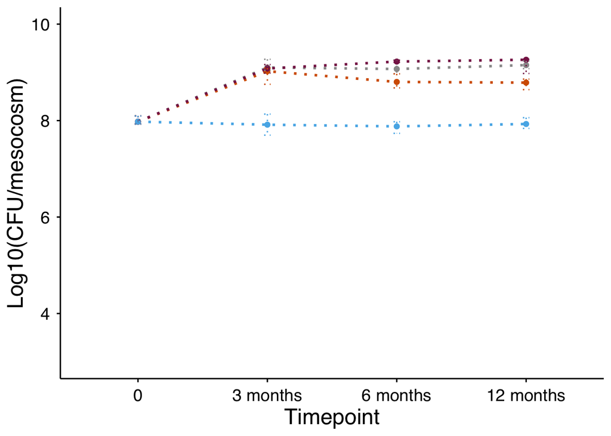

```r
Survival_Mixture <- ggplot(popsize_tube %>% filter(Condition == "Survival", Population_Morphology == "Mixture"),
       aes(x = Timepoint, y = median,
           color = Treatment,
           linetype = Population_Morphology,
           group = interaction(Treatment, Population_Morphology))) +
  geom_point() +
  geom_line(size = 1) +
  geom_errorbar(aes(ymin = min, ymax = max), width = 0.05) +
  scale_color_manual(values = mycols) +
  scale_linetype_manual(values = c("Mixture" = "dotted")) +
  xlab("Timepoint") +
  ylab("Log10(CFU/mesocosm)") +
#  scale_y_log10() +
  coord_cartesian(ylim = c(3, 10)) +
#  facet_wrap(~Condition,  scales = "free_x") +
  theme_minimal(base_size = 12) +
  theme(
    text = element_text(family = "Helvetica", color = "black"),
    axis.text = element_text(size = 14, color = "black"),
    axis.title.x = element_text(size = 18),
    axis.title.y = element_text(size = 18),
    panel.grid = element_blank(),
    axis.line = element_line(color = "black"),
    axis.ticks = element_line(color = "black"),
    legend.position = "none"
  )


Survival_Mixture
```

```r
ggsave(Survival_Mixture,
       filename = here("Phenotype", "Figures" ,"EPS_Figure3B_FromR.pdf"),
       device = "pdf",
       height = 4, width = 5, units = "in")
```

### Percentage dry in mixtures – Survival

```r
### Statistics

aov_Mixed_PercDry_Survival <- aov(Percentage_Dry_ave ~ Treatment*Timepoint, soil.expanded_ave %>%
                                filter(Condition == "Survival" & Population_Morphology == "Mixture")) ## In the ANOVA I am taking into account the timepoint 0
anova_Mixed_PercDry_Survival <- anova(aov_Mixed_PercDry_Survival) #Calculate the anova

anova_Mixed_PercDry_Survival <- rownames_to_column(as.data.frame(anova_Mixed_PercDry_Survival), var = "Term") #For table formating
anova_Mixed_PercDry_Survival
```

```
##                  Term Df    Sum Sq   Mean Sq  F value      Pr(>F)
## 1           Treatment  3  603.6873 201.22910 2.496448 0.067972667
## 2           Timepoint  3 1426.1500 475.38334 5.897606 0.001314537
## 3 Treatment:Timepoint  9 1825.8072 202.86747 2.516774 0.015852797
## 4           Residuals 62 4997.5812  80.60615       NA          NA
```

```r
## Aesthetics

anova_Mixed_PercDry_Survival <- anova_Mixed_PercDry_Survival %>%
  mutate(across(where(is.numeric) & !matches("^Df$"), ~ sprintf("%.3f", .))) %>%
  mutate(`Pr(>F)` = ifelse(as.numeric(`Pr(>F)`) < 0.001, "< 0.001", `Pr(>F)`)) %>%
  dplyr::select(-`Mean Sq`)
write_xlsx(anova_Mixed_PercDry_Survival, here("Phenotype", "Tables", "EPS_TableS8A_FromR.xlsx"))


## I will subset the each treatment and see what timepoints statistically have higher percentage of dry bacteria



### 32 C ###

Survival_32C <- soil.expanded_ave %>% filter(Condition == "Survival" & Population_Morphology == "Mixture", Treatment == "32 °C")

aov_Mixed_PercDry_Survival_32C <- aov(Percentage_Dry_ave ~ Timepoint, Survival_32C)
#summary(aov_Mixed_PercDry_Survival_32C)
anova_Mixed_PercDry_Survival_32C <- anova(aov_Mixed_PercDry_Survival_32C)

anova_Mixed_PercDry_Survival_32C <- rownames_to_column(as.data.frame(anova_Mixed_PercDry_Survival_32C), var = "Term")
anova_Mixed_PercDry_Survival_32C <- anova_Mixed_PercDry_Survival_32C %>% mutate(Treatment = "32 °C")

## Dunnett test

Survival_32C$Timepoint <- relevel(factor(Survival_32C$Timepoint), ref = "0")

aov_Mixed_PercDry_Survival_32C <- aov(Percentage_Dry_ave ~ Timepoint, Survival_32C)

aov_Mixed_PercDry_Survival_32C <- glht(aov_Mixed_PercDry_Survival_32C, linfct = mcp(Timepoint = "Dunnett"))

summary(aov_Mixed_PercDry_Survival_32C)
```

```
##
##   Simultaneous Tests for General Linear Hypotheses
##
## Multiple Comparisons of Means: Dunnett Contrasts
##
##
## Fit: aov(formula = Percentage_Dry_ave ~ Timepoint, data = Survival_32C)
##
## Linear Hypotheses:
##                    Estimate Std. Error t value Pr(>|t|)
## 12 months - 0 == 0   21.403      3.647   5.869  < 0.001 ***
## 3 months - 0 == 0     7.831      3.438   2.278  0.09404 .
## 6 months - 0 == 0    12.861      3.438   3.740  0.00513 **
## ---
## Signif. codes:  0 '***' 0.001 '**' 0.01 '*' 0.05 '.' 0.1 ' ' 1
## (Adjusted p values reported -- single-step method)
```

```r
dunnett_summary <- summary(aov_Mixed_PercDry_Survival_32C)

Dunnett_Mixed_PercDry_Survival_32C <- data.frame(
  Treatment = "32 °C",
  Comparison = names(dunnett_summary$test$coefficients),
  diff = sprintf("%.3f", dunnett_summary$test$coefficients),
  P = ifelse(dunnett_summary$test$pvalues < 0.001, "< 0.001",
             sprintf("%.3f", dunnett_summary$test$pvalues))
)

Dunnett_Mixed_PercDry_Survival_32C
```

```
##   Treatment    Comparison   diff       P
## 1     32 °C 12 months - 0 21.403 < 0.001
## 2     32 °C  3 months - 0  7.831   0.094
## 3     32 °C  6 months - 0 12.861   0.005
```

```r
### 22 C ###

Survival_22C <- soil.expanded_ave %>% filter(Condition == "Survival" & Population_Morphology == "Mixture", Treatment == "22 °C")


aov_Mixed_PercDry_Survival_22C <- aov(Percentage_Dry_ave ~ Timepoint, Survival_22C)
summary(aov_Mixed_PercDry_Survival_22C)
```

```
##             Df Sum Sq Mean Sq F value Pr(>F)
## Timepoint    3  555.6  185.21   7.278 0.0027 **
## Residuals   16  407.2   25.45
## ---
## Signif. codes:  0 '***' 0.001 '**' 0.01 '*' 0.05 '.' 0.1 ' ' 1
```

```r
anova_Mixed_PercDry_Survival_22C <- anova(aov_Mixed_PercDry_Survival_22C)

anova_Mixed_PercDry_Survival_22C <- rownames_to_column(as.data.frame(anova_Mixed_PercDry_Survival_22C), var = "Term")
anova_Mixed_PercDry_Survival_22C <- anova_Mixed_PercDry_Survival_22C %>% mutate(Treatment = "22 °C")

## Dunnett test

Survival_22C$Timepoint <- relevel(factor(Survival_22C$Timepoint), ref = "0")

aov_Mixed_PercDry_Survival_22C <- aov(Percentage_Dry_ave ~ Timepoint, Survival_22C)

aov_Mixed_PercDry_Survival_22C <- glht(aov_Mixed_PercDry_Survival_22C, linfct = mcp(Timepoint = "Dunnett"))
summary(aov_Mixed_PercDry_Survival_22C)
```

```
##
##   Simultaneous Tests for General Linear Hypotheses
##
## Multiple Comparisons of Means: Dunnett Contrasts
##
##
## Fit: aov(formula = Percentage_Dry_ave ~ Timepoint, data = Survival_22C)
##
## Linear Hypotheses:
##                    Estimate Std. Error t value Pr(>|t|)
## 12 months - 0 == 0  13.2440     3.1904   4.151  0.00213 **
## 3 months - 0 == 0    0.7012     3.1904   0.220  0.99235
## 6 months - 0 == 0    4.9164     3.1904   1.541  0.31623
## ---
## Signif. codes:  0 '***' 0.001 '**' 0.01 '*' 0.05 '.' 0.1 ' ' 1
## (Adjusted p values reported -- single-step method)
```

```r
dunnett_summary <- summary(aov_Mixed_PercDry_Survival_22C)

Dunnett_Mixed_PercDry_Survival_22C <- data.frame(
  Treatment = "22 °C",
  Comparison = names(dunnett_summary$test$coefficients),
  diff = sprintf("%.3f", dunnett_summary$test$coefficients),
  P = ifelse(dunnett_summary$test$pvalues < 0.001, "< 0.001",
             sprintf("%.3f", dunnett_summary$test$pvalues))
)

Dunnett_Mixed_PercDry_Survival_22C
```

```
##   Treatment    Comparison   diff     P
## 1     22 °C 12 months - 0 13.244 0.002
## 2     22 °C  3 months - 0  0.701 0.992
## 3     22 °C  6 months - 0  4.916 0.316
```

```r
### Drought ###

Survival_Drought <- soil.expanded_ave %>% filter(Condition == "Survival" & Population_Morphology == "Mixture", Treatment == "Drought")

aov_Mixed_PercDry_Survival_DroughtC <- aov(Percentage_Dry_ave ~ Timepoint, Survival_Drought)
summary(aov_Mixed_PercDry_Survival_DroughtC)
```

```
##             Df Sum Sq Mean Sq F value Pr(>F)
## Timepoint    3    132   44.14    0.17  0.915
## Residuals   15   3887  259.12
```

```r
anova_Mixed_PercDry_Survival_DroughtC <- anova(aov_Mixed_PercDry_Survival_DroughtC)

anova_Mixed_PercDry_Survival_DroughtC <- rownames_to_column(as.data.frame(anova_Mixed_PercDry_Survival_DroughtC), var = "Term")
anova_Mixed_PercDry_Survival_DroughtC <- anova_Mixed_PercDry_Survival_DroughtC %>% mutate(Treatment = "Drought")


### Dunnett test

Survival_Drought$Timepoint <- relevel(factor(Survival_Drought$Timepoint), ref = "0")

aov_Mixed_PercDry_Survival_DroughtC <- aov(Percentage_Dry_ave ~ Timepoint, Survival_Drought)

aov_Mixed_PercDry_Survival_DroughtC <- glht(aov_Mixed_PercDry_Survival_DroughtC, linfct = mcp(Timepoint = "Dunnett"))
summary(aov_Mixed_PercDry_Survival_DroughtC)
```

```
##
##   Simultaneous Tests for General Linear Hypotheses
##
## Multiple Comparisons of Means: Dunnett Contrasts
##
##
## Fit: aov(formula = Percentage_Dry_ave ~ Timepoint, data = Survival_Drought)
##
## Linear Hypotheses:
##                    Estimate Std. Error t value Pr(>|t|)
## 12 months - 0 == 0   4.2760    10.1807   0.420    0.953
## 3 months - 0 == 0    5.3284    10.1807   0.523    0.916
## 6 months - 0 == 0   -0.8868    10.7983  -0.082    1.000
## (Adjusted p values reported -- single-step method)
```

```r
dunnett_summary <- summary(aov_Mixed_PercDry_Survival_DroughtC)

Dunnett_Mixed_PercDry_Survival_Drought <- data.frame(
  Treatment = "Drought",
  Comparison = names(dunnett_summary$test$coefficients),
  diff = sprintf("%.3f", dunnett_summary$test$coefficients),
  P = ifelse(dunnett_summary$test$pvalues < 0.001, "< 0.001",
             sprintf("%.3f", dunnett_summary$test$pvalues))
)

Dunnett_Mixed_PercDry_Survival_Drought
```

```
##   Treatment    Comparison   diff     P
## 1   Drought 12 months - 0  4.276 0.953
## 2   Drought  3 months - 0  5.328 0.916
## 3   Drought  6 months - 0 -0.887 1.000
```

```r
### 4 C ###

Survival_4C <- soil.expanded_ave %>% filter(Condition == "Survival" & Population_Morphology == "Mixture", Treatment == "4 °C")

aov_Mixed_PercDry_Survival_4C <- aov(Percentage_Dry_ave ~ Timepoint, Survival_4C)
summary(aov_Mixed_PercDry_Survival_4C)
```

```
##             Df Sum Sq Mean Sq F value   Pr(>F)
## Timepoint    3 1479.4   493.1   30.31 7.82e-07 ***
## Residuals   16  260.3    16.3
## ---
## Signif. codes:  0 '***' 0.001 '**' 0.01 '*' 0.05 '.' 0.1 ' ' 1
```

```r
anova_Mixed_PercDry_Survival_4C <- anova(aov_Mixed_PercDry_Survival_4C)

anova_Mixed_PercDry_Survival_4C <- rownames_to_column(as.data.frame(anova_Mixed_PercDry_Survival_4C), var = "Term")
anova_Mixed_PercDry_Survival_4C <- anova_Mixed_PercDry_Survival_4C %>% mutate(Treatment = "4 °C")

### Dunnett test

Survival_4C$Timepoint <- relevel(factor(Survival_4C$Timepoint), ref = "0")

aov_Mixed_PercDry_Survival_4C <- aov(Percentage_Dry_ave ~ Timepoint, Survival_4C)

aov_Mixed_PercDry_Survival_4C <- glht(aov_Mixed_PercDry_Survival_4C, linfct = mcp(Timepoint = "Dunnett"))
summary(aov_Mixed_PercDry_Survival_4C)
```

```
##
##   Simultaneous Tests for General Linear Hypotheses
##
## Multiple Comparisons of Means: Dunnett Contrasts
##
##
## Fit: aov(formula = Percentage_Dry_ave ~ Timepoint, data = Survival_4C)
##
## Linear Hypotheses:
##                    Estimate Std. Error t value Pr(>|t|)
## 12 months - 0 == 0    6.212      2.551   2.435   0.0677 .
## 3 months - 0 == 0    17.156      2.551   6.725   <0.001 ***
## 6 months - 0 == 0    -6.114      2.551  -2.397   0.0729 .
## ---
## Signif. codes:  0 '***' 0.001 '**' 0.01 '*' 0.05 '.' 0.1 ' ' 1
## (Adjusted p values reported -- single-step method)
```

```r
dunnett_summary <- summary(aov_Mixed_PercDry_Survival_4C)

Dunnett_Mixed_PercDry_Survival_4C <- data.frame(
  Treatment = "4 °C",
  Comparison = names(dunnett_summary$test$coefficients),
  diff = sprintf("%.3f", dunnett_summary$test$coefficients),
  P = ifelse(dunnett_summary$test$pvalues < 0.001, "< 0.001",
             sprintf("%.3f", dunnett_summary$test$pvalues))
)

Dunnett_Mixed_PercDry_Survival_4C
```

```
##   Treatment    Comparison   diff       P
## 1      4 °C 12 months - 0  6.212   0.068
## 2      4 °C  3 months - 0 17.156 < 0.001
## 3      4 °C  6 months - 0 -6.114   0.073
```

```r
#### Compile the Anovas ####


Anova_Survival_soil_Treatments <- bind_rows(anova_Mixed_PercDry_Survival_32C, anova_Mixed_PercDry_Survival_22C, anova_Mixed_PercDry_Survival_4C, anova_Mixed_PercDry_Survival_DroughtC)
Anova_Survival_soil_Treatments
```

```
##        Term Df    Sum Sq   Mean Sq    F value       Pr(>F) Treatment
## 1 Timepoint  3 1084.4888 361.49625 12.2312769 2.608343e-04     32 °C
## 2 Residuals 15  443.3261  29.55507         NA           NA     32 °C
## 3 Timepoint  3  555.6346 185.21154  7.2782994 2.696231e-03     22 °C
## 4 Residuals 16  407.1534  25.44709         NA           NA     22 °C
## 5 Timepoint  3 1479.4142 493.13807 30.3076061 7.815099e-07      4 °C
## 6 Residuals 16  260.3376  16.27110         NA           NA      4 °C
## 7 Timepoint  3  132.4196  44.13988  0.1703469 9.147461e-01   Drought
## 8 Residuals 15 3886.7641 259.11761         NA           NA   Drought
```

```r
Anova_Survival_soil_Treatments <- Anova_Survival_soil_Treatments %>%
  mutate(across(where(is.numeric) & !matches("^Df$"), ~ sprintf("%.3f", .))) %>%
  mutate(`Pr(>F)` = ifelse(as.numeric(`Pr(>F)`) < 0.001, "< 0.001", `Pr(>F)`)) %>%
  dplyr::select(-`Mean Sq`) %>%
  dplyr::select("Treatment", "Term", "Df", "Sum Sq", "F value", "Pr(>F)")
Anova_Survival_soil_Treatments
```

```
##   Treatment      Term Df   Sum Sq F value  Pr(>F)
## 1     32 °C Timepoint  3 1084.489  12.231 < 0.001
## 2     32 °C Residuals 15  443.326      NA    <NA>
## 3     22 °C Timepoint  3  555.635   7.278   0.003
## 4     22 °C Residuals 16  407.153      NA    <NA>
## 5      4 °C Timepoint  3 1479.414  30.308 < 0.001
## 6      4 °C Residuals 16  260.338      NA    <NA>
## 7   Drought Timepoint  3  132.420   0.170   0.915
## 8   Drought Residuals 15 3886.764      NA    <NA>
```

```r
write_xlsx(Anova_Survival_soil_Treatments, here("Phenotype", "Tables", "EPS_TableS8B_FromR.xlsx"))


#### Compile the Dunnett tests ####

dunnett_Survival_all <- rbind(Dunnett_Mixed_PercDry_Survival_32C, Dunnett_Mixed_PercDry_Survival_22C, Dunnett_Mixed_PercDry_Survival_4C, Dunnett_Mixed_PercDry_Survival_Drought)
dunnett_Survival_all
```

```
##    Treatment    Comparison   diff       P
## 1      32 °C 12 months - 0 21.403 < 0.001
## 2      32 °C  3 months - 0  7.831   0.094
## 3      32 °C  6 months - 0 12.861   0.005
## 4      22 °C 12 months - 0 13.244   0.002
## 5      22 °C  3 months - 0  0.701   0.992
## 6      22 °C  6 months - 0  4.916   0.316
## 7       4 °C 12 months - 0  6.212   0.068
## 8       4 °C  3 months - 0 17.156 < 0.001
## 9       4 °C  6 months - 0 -6.114   0.073
## 10   Drought 12 months - 0  4.276   0.953
## 11   Drought  3 months - 0  5.328   0.916
## 12   Drought  6 months - 0 -0.887   1.000
```

```r
write_xlsx(dunnett_Survival_all, here("Phenotype", "Tables", "EPS_TableS8C_FromR.xlsx"))
```

###### Percentage of Dry bacteria

```r
Survival_Mesocosm_Mixture_initial_ave <- soil.expanded_ave %>% filter(Condition == "Survival" & Population_Morphology == "Mixture" & Timepoint == "0")

Initial_ave_growth <- Survival_Mesocosm_Mixture_initial_ave %>%
  ungroup() %>%
  summarise(Initial_ave_growth = mean(Percentage_Dry_ave, na.rm = TRUE)) %>%
  pull(Initial_ave_growth)

Initial_ave_growth
```

```
## [1] 49.67758
```

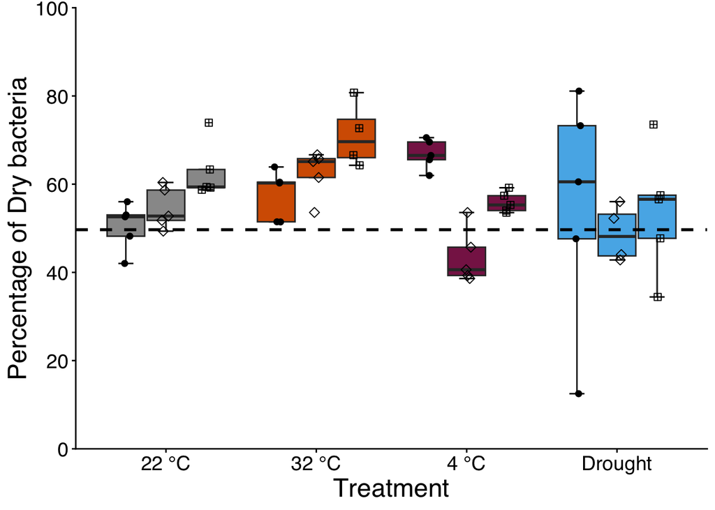

```r
Survival_DryPercentage <- ggplot(data = soil.expanded_ave %>%
                                   filter(Condition == "Survival" & Population_Morphology == "Mixture" & Timepoint != "0") %>%
                                   mutate(Timepoint = factor(Timepoint, levels = c("3 months", "6 months", "12 months"))),
  aes(x = Treatment, y = Percentage_Dry_ave, fill = Treatment, group = interaction(Treatment, Timepoint))) +
  stat_boxplot(geom = "errorbar", width = 0.3, color = "black", position = position_dodge(width = 0.8)) +
  geom_boxplot(outlier.shape = NA, position = position_dodge(width = 0.8)) +
  geom_jitter(aes(shape = Timepoint), position = position_jitterdodge(jitter.width = 0.15, dodge.width = 0.8), size = 2, color = "black") +
  scale_shape_manual(values = myshapes_survival) +
  scale_fill_manual(values = mycols) +
  scale_y_continuous(limits = c(0, 100), breaks = seq(0, 100, 20), expand = c(0, 0)) +
  geom_hline(yintercept= Initial_ave_growth, linetype="dashed", color="black", size=1) +
  labs(x = "Treatment", y = "Percentage of Dry bacteria") +
  theme_classic() +
  theme(
    text = element_text(family = "Helvetica", color = "black"),
    axis.text = element_text(size = 14, color = "black"),
    axis.title.x = element_text(size = 18),
    axis.title.y = element_text(size = 18),
    panel.grid = element_blank(),
    axis.line = element_line(color = "black"),
    axis.ticks = element_line(color = "black"),
    legend.position = "none")

Survival_DryPercentage
```

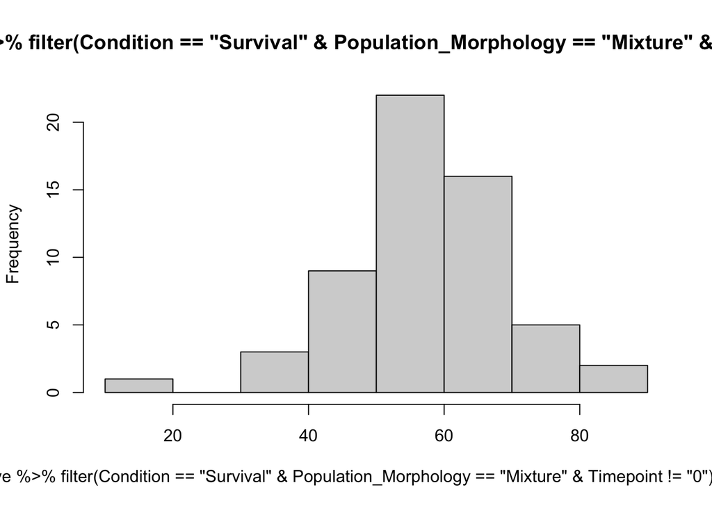

```r
ggsave(Survival_DryPercentage,
       filename = here("Phenotype", "Figures","EPS_Figure3D_FromR.pdf"),
       device = "pdf",
       height = 4, width = 5, units = "in")

## This looks normaly distributed
hist((soil.expanded_ave %>% filter(Condition == "Survival" & Population_Morphology == "Mixture" & Timepoint != "0"))$Percentage_Dry_ave)
```

#### Mucoid

##### Mucoid - Growth and Survival

There was a shift from Mucoid to Dry

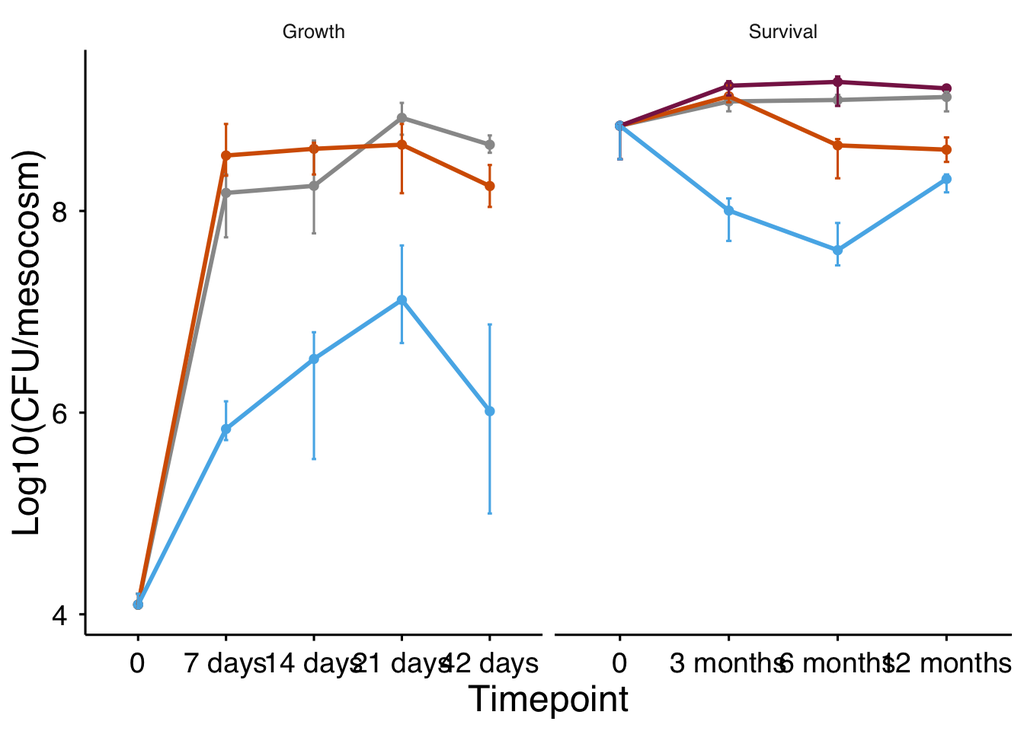

```r
Growth_Survival_Mucoid <- ggplot(popsize_tube %>% filter(Population_Morphology == "Mucoid"),
       aes(x = Timepoint, y = median,
           color = Treatment,
           linetype = Population_Morphology,
           group = interaction(Treatment, Population_Morphology))) +
  geom_point() +
  geom_line(size = 1) +
  geom_errorbar(aes(ymin = min, ymax = max), width = 0.05) +
  scale_color_manual(values = mycols) +
  scale_linetype_manual(values = c("Mucoid" = "solid", "Dry" = "dashed")) +
  xlab("Timepoint") +
  ylab("Log10(CFU/mesocosm)") +
#  scale_y_log10() +
  facet_wrap(~Condition,  scales = "free_x") +
  theme_minimal(base_size = 12) +
  theme(
    text             = element_text(family = "Helvetica", color = "black"),
    axis.text        = element_text(size = 14, color = "black"),
    axis.title.x     = element_text(size = 18, color = "black"),
    axis.title.y     = element_text(size = 18, color = "black"),
    panel.grid       = element_blank(),
    axis.line        = element_line(color = "black"),
    axis.ticks       = element_line(color = "black"),
    legend.position  = "none")


Growth_Survival_Mucoid
```

```r
ggsave(Growth_Survival_Mucoid,
       filename = here("Phenotype", "Figures" ,"EPS_FigureS5AB_FromR.pdf"),
       device = "pdf",
       height = 5, width = 9, units = "in")
```

##### Mucoid shift: Survival and Growth

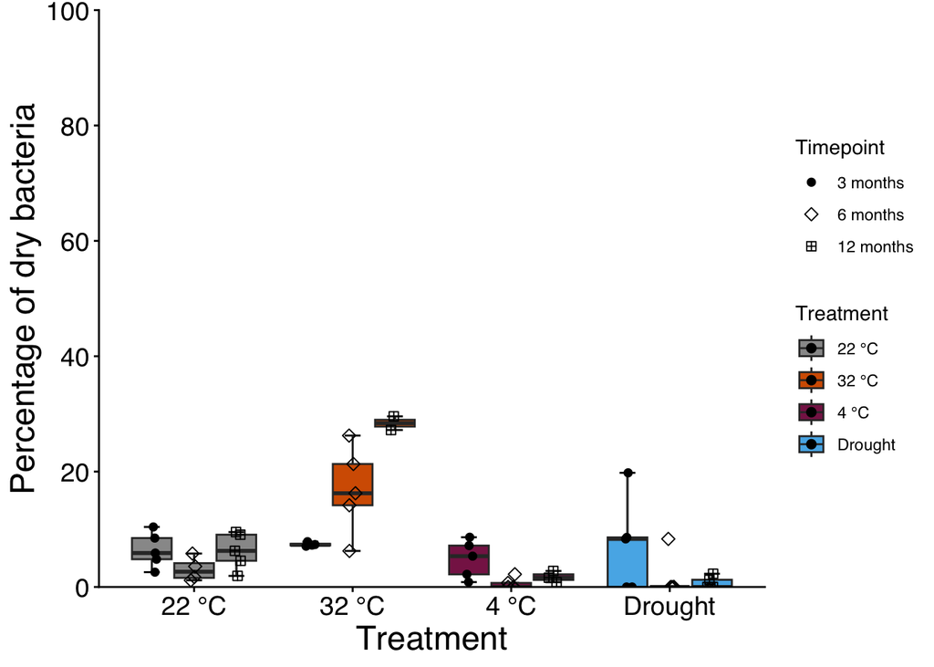

```r
#### Survival ####

Survival_Mesocosm_Mucoid_NoIn <- soil.expanded_ave %>% filter(Condition == "Survival" & Population_Morphology == "Mucoid" & Timepoint != "0")

Shift_Mucoid_Dry_Soil_Survival <- ggplot(Survival_Mesocosm_Mucoid_NoIn %>%
                                          mutate(Timepoint = factor(Timepoint, levels = c("3 months", "6 months", "12 months"))),
                                         aes(x = Treatment, y = Percentage_Dry_ave, fill = Treatment, group = interaction(Treatment, Timepoint))) +
  stat_boxplot(geom = "errorbar", width = 0.3, color = "black", position = position_dodge(width = 0.8)) +
  geom_boxplot(outlier.shape = NA, position = position_dodge(width = 0.8)) +
  geom_jitter(aes(shape = Timepoint), position = position_jitterdodge(jitter.width = 0.15, dodge.width = 0.8), size = 2, color = "black") +
  scale_shape_manual(values = myshapes_survival) +
  scale_fill_manual(values = mycols) +
  scale_y_continuous(limits = c(0, 100), breaks = seq(0, 100, 20), expand = c(0, 0)) +
  labs(x = "Treatment", y = "Percentage of dry bacteria") +
  theme_classic() +
  theme(
    text             = element_text(family = "Helvetica", color = "black"),
    axis.text        = element_text(size = 14, color = "black"),
    axis.title.x     = element_text(size = 18, color = "black"),
    axis.title.y     = element_text(size = 18, color = "black"),
    panel.grid       = element_blank(),
    axis.line        = element_line(color = "black"),
    axis.ticks       = element_line(color = "black")
#    legend.position  = "none"
)

Shift_Mucoid_Dry_Soil_Survival
```

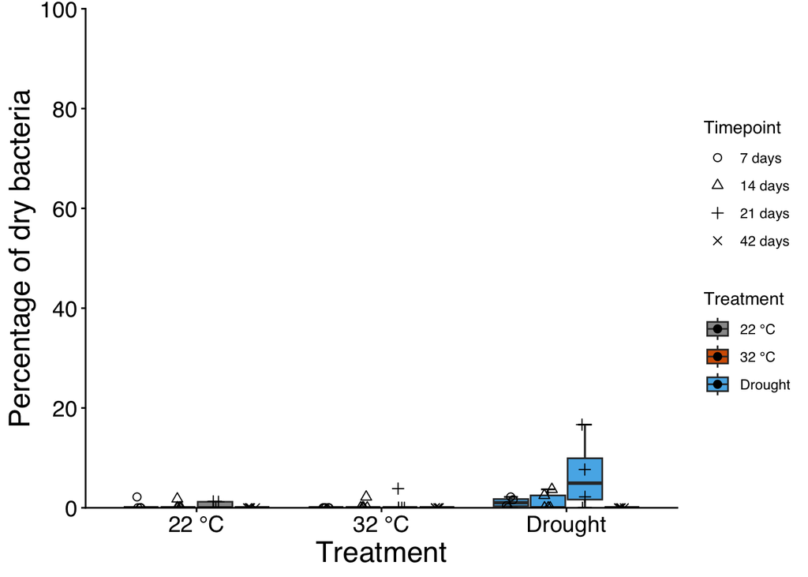

```r
ggsave(Shift_Mucoid_Dry_Soil_Survival,
       filename= here("Phenotype", "Figures", "EPS_FigureS5D_FromR.pdf"),
       device = "pdf",
       height = 5, width = 6, units = "in")




#### Growth ####

Growth_Mesocosm_Mucoid_NoIn <- soil.expanded_ave %>% filter(Condition == "Growth" & Population_Morphology == "Mucoid" & Timepoint != "0")


Shift_Mucoid_Dry_Soil_Growth <- ggplot(Growth_Mesocosm_Mucoid_NoIn %>%
                                          mutate(Timepoint = factor(Timepoint, levels = c("7 days", "14 days", "21 days", "42 days"))),
                                         aes(x = Treatment, y = Percentage_Dry_ave, fill = Treatment, group = interaction(Treatment, Timepoint))) +
  stat_boxplot(geom = "errorbar", width = 0.3, color = "black", position = position_dodge(width = 0.8)) +
  geom_boxplot(outlier.shape = NA, position = position_dodge(width = 0.8)) +
  geom_jitter(aes(shape = Timepoint), position = position_jitterdodge(jitter.width = 0.15, dodge.width = 0.8), size = 2, color = "black") +
  scale_shape_manual(values = myshapes_growth) +
  scale_fill_manual(values = mycols) +
  scale_y_continuous(limits = c(0, 100), breaks = seq(0, 100, 20), expand = c(0, 0)) +
  labs(x = "Treatment", y = "Percentage of dry bacteria") +
  theme_classic() +
  theme(
    text             = element_text(family = "Helvetica", color = "black"),
    axis.text        = element_text(size = 14, color = "black"),
    axis.title.x     = element_text(size = 18, color = "black"),
    axis.title.y     = element_text(size = 18, color = "black"),
    panel.grid       = element_blank(),
    axis.line        = element_line(color = "black"),
    axis.ticks       = element_line(color = "black")
#    legend.position  = "none"
)

Shift_Mucoid_Dry_Soil_Growth
```

```r
ggsave(Shift_Mucoid_Dry_Soil_Growth,
       filename= here("Phenotype", "Figures", "EPS_FigureS5C_FromR.pdf"),
       device = "pdf",
       height = 5, width = 6, units = "in")
```

#### Dry

##### Dry - Growth and Survival

This might be the wrong approach but I think results wise, it is better if dry bacteria is compared to mucoid bacteria in the same plots so I will do that.

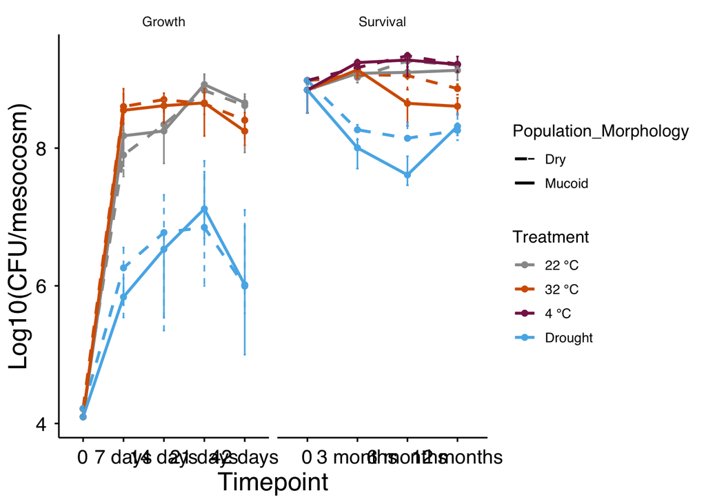

```r
#### Growth and Survival for both mucoid and dry bacteria

Growth_Survival_DryMucoid <- ggplot(popsize_tube %>% filter(Population_Morphology %in% c("Dry", "Mucoid")),
       aes(x = Timepoint, y = median,
           color = Treatment,
           linetype = Population_Morphology,
           group = interaction(Treatment, Population_Morphology))) +
  geom_point() +
  geom_line(size = 1) +
  geom_errorbar(aes(ymin = min, ymax = max), width = 0.05) +
  scale_color_manual(values = mycols) +
  scale_linetype_manual(values = c("Mucoid" = "solid", "Dry" = "dashed")) +
  xlab("Timepoint") +
  ylab("Log10(CFU/mesocosm)") +
#  scale_y_log10() +
  facet_wrap(~Condition,  scales = "free_x") +
  theme_minimal(base_size = 12) +
  theme(
    text             = element_text(family = "Helvetica", color = "black"),
    axis.text        = element_text(size = 14, color = "black"),
    axis.title.x     = element_text(size = 18, color = "black"),
    axis.title.y     = element_text(size = 18, color = "black"),
    panel.grid       = element_blank(),
    axis.line        = element_line(color = "black"),
    axis.ticks       = element_line(color = "black")
#    legend.position  = "none"
)


Growth_Survival_DryMucoid
```

```r
ggsave(Growth_Survival_DryMucoid,
       filename = here("Phenotype", "Figures" ,"EPS_FigureS4_FromR.pdf"),
       device = "pdf",
       height = 5, width = 11, units = "in")
```

### PLANT

Open the files

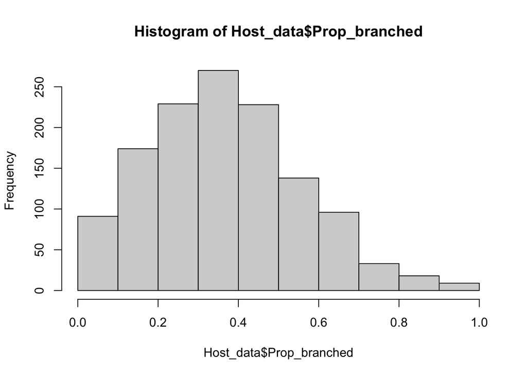

```r
######## PLANT TRAITS ##################

### Data that contains the results from the single inoculation experiments that contains plant fitness data (shoot biomass) and nodule number

Host_data <-  read.csv(here("Phenotype", "Data_input", "Single_Strain_Experiment_Host.csv")) #Here rep is the block
#View(Host_data)

### Find total nodule number

Host_data <- Host_data %>%
  mutate(Nod_number = as.numeric(Nodule_LOBED) + as.numeric(Nodule_UN_Lobed),
         Prop_branched = as.numeric(Nodule_LOBED)/Nod_number)

hist(Host_data$Prop_branched) #Shows normal distribution
```

```r
####### RHIZOBIA RELATIVE FREQUENCY ######

### Data coming from the multi-strain inoculation experiments that contains rhizobial strain fitness

Freq_data <-  read.table(here("Phenotype", "Data_input", "freq_100_AVT118.tsv"), header = TRUE, sep = "")
#View(Freq_data)

Freq_data <- Freq_data %>%
  separate(col = pool,
           into = c("AG", "Type", "Variety", "Rep"),
           sep = "_",
           remove = FALSE,
           fill = "right"
  )
#View(Freq_data)

Freq_data_MIX <- Freq_data %>% filter(Type == "MIX") ## Remove MC2
#View(Freq_data_MIX)
Freq_data_MIX <- Freq_data_MIX %>%
  mutate(Variety = if_else(Variety %in% c("1", "2", "3", "4"), "Initial", Variety))

Initial_Freq_data_MIX <- Freq_data_MIX %>% filter(Variety == "Initial")
Initial_Freq_data_MIX
```

```
##       pool AG Type Variety  Rep       AVT1      AVT10     AVT100     AVT101
## 1 AG_MIX_1 AG  MIX Initial <NA> 0.00752803 0.00752910 0.00725204 0.00822483
## 2 AG_MIX_2 AG  MIX Initial <NA> 0.00752642 0.00756617 0.00735598 0.00842335
## 3 AG_MIX_3 AG  MIX Initial <NA> 0.00751959 0.00751671 0.00724685 0.00837031
## 4 AG_MIX_4 AG  MIX Initial <NA> 0.00741967 0.00741316 0.00733728 0.00812670
##       AVT102     AVT103     AVT104     AVT105     AVT106     AVT107     AVT108
## 1 0.00803595 0.00756357 0.01007870 0.00575718 0.00530394 0.00987277 0.00924668
## 2 0.00846044 0.00754171 0.00991301 0.00600139 0.00548809 0.00975061 0.00957148
## 3 0.00843934 0.00752239 0.01002720 0.00592012 0.00527784 0.00971795 0.00954974
## 4 0.00845940 0.00746943 0.01000520 0.00587930 0.00567174 0.00975915 0.00926977
##       AVT109      AVT11     AVT110    AVT111     AVT112     AVT113     AVT114
## 1 0.00867014 0.00993242 0.00731325 0.0100749 0.01007260 0.00855352 0.00870089
## 2 0.00900321 0.00978776 0.00743200 0.0098998 0.00993608 0.00883740 0.00899998
## 3 0.00959596 0.00981702 0.00740556 0.0099666 0.01010640 0.00949091 0.00958068
## 4 0.00908780 0.00983943 0.00740245 0.0099385 0.01000270 0.00897234 0.00909434
```

[output cut: 75 more lines]

```r
Freq_data_NoInitial <- Freq_data_MIX %>% filter(Variety != "Initial")
Freq_data_NoInitial
```

```
##          pool AG Type Variety Rep       AVT1      AVT10     AVT100     AVT101
## 1  AG_MIX_O_A AG  MIX       O   A 0.01079130 0.01076920 0.00470169 0.00600933
## 2  AG_MIX_O_B AG  MIX       O   B 0.00600252 0.00598950 0.00377387 0.01580030
## 3  AG_MIX_O_C AG  MIX       O   C 0.00646840 0.00643599 0.00457090 0.00408138
## 4  AG_MIX_O_D AG  MIX       O   D 0.00835749 0.00835805 0.00322257 0.00570679
## 5  AG_MIX_O_E AG  MIX       O   E 0.00895649 0.00892890 0.00471206 0.00587007
## 6  AG_MIX_O_F AG  MIX       O   F 0.00346633 0.00345783 0.00198868 0.00459695
## 7  AG_MIX_O_G AG  MIX       O   G 0.01409210 0.01402870 0.00385308 0.00877530
## 8  AG_MIX_O_H AG  MIX       O   H 0.01024310 0.01023770 0.00253313 0.00476745
## 9  AG_MIX_S_A AG  MIX       S   A 0.00666893 0.00663596 0.00165392 0.00683844
## 10 AG_MIX_S_B AG  MIX       S   B 0.00762661 0.00758967 0.00395090 0.00436641
## 11 AG_MIX_S_C AG  MIX       S   C 0.00800621 0.00798194 0.00402666 0.00775007
## 12 AG_MIX_S_D AG  MIX       S   D 0.01057570 0.01089870 0.00457404 0.01221930
## 13 AG_MIX_S_E AG  MIX       S   E 0.00710946 0.00726479 0.00174148 0.00442025
## 14 AG_MIX_S_F AG  MIX       S   F 0.01208450 0.01208060 0.00367989 0.00554315
```

[output cut: 384 more lines]

```r
## Calculate the fitness

Initial_Freq_data_MIX <-apply((Initial_Freq_data_MIX[,c(-1:-5)]), 2, mean) # The "2" specified that the mean should be found per column.
Initial_Freq_data_MIX
```

```
##        AVT1       AVT10      AVT100      AVT101      AVT102      AVT103
## 0.007498427 0.007506285 0.007298038 0.008286298 0.008348783 0.007524275
##      AVT104      AVT105      AVT106      AVT107      AVT108      AVT109
## 0.010006028 0.005889498 0.005435403 0.009775120 0.009409417 0.009089277
##       AVT11      AVT110      AVT111      AVT112      AVT113      AVT114
## 0.009844157 0.007388315 0.009969950 0.010029445 0.008963543 0.009093972
##      AVT115      AVT116      AVT117      AVT118      AVT119       AVT12
## 0.006591712 0.007660040 0.009939645 0.009984537 0.009851192 0.008222547
##      AVT120      AVT121      AVT122      AVT123       AVT13       AVT14
## 0.007597728 0.008326925 0.007278977 0.006580260 0.009525315 0.007655887
##       AVT15       AVT16       AVT17       AVT18       AVT19        AVT2
## 0.007513337 0.007329622 0.009688853 0.005905725 0.008301952 0.009783962
##       AVT20       AVT21       AVT22       AVT23       AVT24       AVT25
## 0.007512543 0.009439058 0.007501380 0.009539637 0.009457155 0.004584015
##       AVT26       AVT28       AVT29        AVT3       AVT30       AVT31
## 0.009752295 0.008436232 0.008307317 0.009620708 0.009818457 0.009804587
##       AVT32       AVT33       AVT34       AVT35       AVT37       AVT38
## 0.009809060 0.005477910 0.007523813 0.007377180 0.009808723 0.009750492
##       AVT39        AVT4       AVT41       AVT42       AVT43       AVT44
## 0.009517080 0.009772372 0.009857435 0.009826760 0.009811933 0.009884977
##       AVT45       AVT46       AVT47       AVT48       AVT49        AVT5
## 0.009854800 0.009875762 0.009294017 0.010003597 0.010011790 0.007582183
##       AVT50       AVT52       AVT53       AVT54       AVT55       AVT56
## 0.009831652 0.010012595 0.009798890 0.009341790 0.009881987 0.009852590
##       AVT57       AVT58       AVT59        AVT6       AVT60       AVT62
## 0.009753715 0.009872045 0.009818180 0.007684402 0.009857925 0.007525690
##       AVT63       AVT64       AVT65       AVT67       AVT68       AVT69
## 0.009817237 0.009388705 0.007124705 0.007267865 0.009747182 0.007541425
##        AVT7       AVT70       AVT71       AVT72       AVT73       AVT74
## 0.007492370 0.007536162 0.007495820 0.007471607 0.009755935 0.006618910
##       AVT75       AVT76       AVT77       AVT78       AVT79        AVT8
## 0.009754202 0.006545182 0.007440560 0.009984480 0.006611387 0.009463333
##       AVT80       AVT81       AVT82       AVT83       AVT84       AVT85
## 0.009791285 0.007053595 0.006558413 0.009799395 0.007523798 0.007596450
##       AVT86       AVT87       AVT88       AVT89        AVT9       AVT90
## 0.009981502 0.009427065 0.007510122 0.007435003 0.009741203 0.009823780
##       AVT91       AVT92       AVT93       AVT94       AVT95       AVT96
## 0.007302505 0.005473677 0.010020537 0.009296667 0.006594880 0.007738295
##       AVT97       AVT98       AVT99
## 0.007293547 0.008310912 0.007531137
```

```r
Freq_data_NoInitial
```

```
##          pool AG Type Variety Rep       AVT1      AVT10     AVT100     AVT101
## 1  AG_MIX_O_A AG  MIX       O   A 0.01079130 0.01076920 0.00470169 0.00600933
## 2  AG_MIX_O_B AG  MIX       O   B 0.00600252 0.00598950 0.00377387 0.01580030
## 3  AG_MIX_O_C AG  MIX       O   C 0.00646840 0.00643599 0.00457090 0.00408138
## 4  AG_MIX_O_D AG  MIX       O   D 0.00835749 0.00835805 0.00322257 0.00570679
## 5  AG_MIX_O_E AG  MIX       O   E 0.00895649 0.00892890 0.00471206 0.00587007
## 6  AG_MIX_O_F AG  MIX       O   F 0.00346633 0.00345783 0.00198868 0.00459695
## 7  AG_MIX_O_G AG  MIX       O   G 0.01409210 0.01402870 0.00385308 0.00877530
## 8  AG_MIX_O_H AG  MIX       O   H 0.01024310 0.01023770 0.00253313 0.00476745
## 9  AG_MIX_S_A AG  MIX       S   A 0.00666893 0.00663596 0.00165392 0.00683844
## 10 AG_MIX_S_B AG  MIX       S   B 0.00762661 0.00758967 0.00395090 0.00436641
## 11 AG_MIX_S_C AG  MIX       S   C 0.00800621 0.00798194 0.00402666 0.00775007
## 12 AG_MIX_S_D AG  MIX       S   D 0.01057570 0.01089870 0.00457404 0.01221930
## 13 AG_MIX_S_E AG  MIX       S   E 0.00710946 0.00726479 0.00174148 0.00442025
## 14 AG_MIX_S_F AG  MIX       S   F 0.01208450 0.01208060 0.00367989 0.00554315
```

[output cut: 384 more lines]

```r
Sub_Freq <- Freq_data_NoInitial[, -c(1:5)]
Sub_Freq
```

```
##          AVT1      AVT10     AVT100     AVT101     AVT102     AVT103     AVT104
## 1  0.01079130 0.01076920 0.00470169 0.00600933 0.01168420 0.01077920 0.00864920
## 2  0.00600252 0.00598950 0.00377387 0.01580030 0.02094910 0.00599113 0.01173280
## 3  0.00646840 0.00643599 0.00457090 0.00408138 0.00727629 0.00648312 0.00842218
## 4  0.00835749 0.00835805 0.00322257 0.00570679 0.00874196 0.00834633 0.01139150
## 5  0.00895649 0.00892890 0.00471206 0.00587007 0.00418297 0.00899471 0.00927697
## 6  0.00346633 0.00345783 0.00198868 0.00459695 0.00904821 0.00346505 0.01241190
## 7  0.01409210 0.01402870 0.00385308 0.00877530 0.01558140 0.01404200 0.00884735
## 8  0.01024310 0.01023770 0.00253313 0.00476745 0.00703233 0.01032990 0.00846639
## 9  0.00666893 0.00663596 0.00165392 0.00683844 0.00667994 0.00721392 0.01120470
## 10 0.00762661 0.00758967 0.00395090 0.00436641 0.00596976 0.00772691 0.00937733
## 11 0.00800621 0.00798194 0.00402666 0.00775007 0.00832253 0.00801169 0.00648949
## 12 0.01057570 0.01089870 0.00457404 0.01221930 0.02037970 0.01056620 0.00808219
## 13 0.00710946 0.00726479 0.00174148 0.00442025 0.00720402 0.00710477 0.00892897
## 14 0.01208450 0.01208060 0.00367989 0.00554315 0.01100680 0.01212580 0.00878469
```

[output cut: 363 more lines]

```r
normalized <- sweep(as.matrix(Sub_Freq), 2, Initial_Freq_data_MIX[colnames(Sub_Freq)], FUN = "/")
normalized
```

```
##            AVT1     AVT10    AVT100    AVT101    AVT102    AVT103    AVT104
##  [1,] 1.4391417 1.4346911 0.6442403 0.7252129 1.3995094 1.4325899 0.8643990
##  [2,] 0.8005038 0.7979313 0.5171075 1.9067985 2.5092401 0.7962402 1.1725732
##  [3,] 0.8626342 0.8574135 0.6263191 0.4925457 0.8715391 0.8616272 0.8417107
##  [4,] 1.1145657 1.1134736 0.4415667 0.6887020 1.0470940 1.1092537 1.1384638
##  [5,] 1.1944491 1.1895232 0.6456612 0.7084069 0.5010275 1.1954255 0.9271382
##  [6,] 0.4622743 0.4606580 0.2724952 0.5547653 1.0837760 0.4605161 1.2404423
##  [7,] 1.8793407 1.8689272 0.5279611 1.0590134 1.8663081 1.8662263 0.8842020
##  [8,] 1.3660331 1.3638837 0.3470974 0.5753414 0.8423180 1.3728765 0.8461290
##  [9,] 0.8893771 0.8840538 0.2266253 0.8252709 0.8001095 0.9587528 1.1197950
## [10,] 1.0170946 1.0111087 0.5413647 0.5269434 0.7150456 1.0269308 0.9371681
## [11,] 1.0677185 1.0633676 0.5517456 0.9352874 0.9968555 1.0647790 0.6485581
## [12,] 1.4103890 1.4519433 0.6267493 1.4746393 2.4410386 1.4042815 0.8077321
## [13,] 0.9481268 0.9678276 0.2386231 0.5334409 0.8628827 0.9442465 0.8923591
## [14,] 1.6116046 1.6093980 0.5042301 0.6689538 1.3183719 1.6115573 0.8779398
```

[output cut: 342 more lines]

```r
## Calculate the fitness

meso_fit <-as_tibble(cbind(Freq_data_NoInitial[,c(1:5)],log2(normalized))) #Find the log2 of the division and add back the information

#View(meso_fit)

## There are some that have a -Inf so I will replace it with -8

meso_fit <- meso_fit %>%
  mutate(across(where(is.numeric), ~ ifelse(. == -Inf, -8, .)))
#View(meso_fit)


### Represent the values in the long format to be able to paste the values for Morphology


meso_fit_long <- meso_fit %>%
  pivot_longer(
    cols = -c(Variety,Rep,pool, AG, Type, Variety, Rep),
    names_to = "Strain_Code",
    values_to = "Fitness"
  )
meso_fit_long
```

```
## # A tibble: 2,340 × 7
##    pool       AG    Type  Variety Rep   Strain_Code Fitness
##    <chr>      <chr> <chr> <chr>   <chr> <chr>         <dbl>
##  1 AG_MIX_O_A AG    MIX   O       A     AVT1          0.525
##  2 AG_MIX_O_A AG    MIX   O       A     AVT10         0.521
##  3 AG_MIX_O_A AG    MIX   O       A     AVT100       -0.634
##  4 AG_MIX_O_A AG    MIX   O       A     AVT101       -0.464
##  5 AG_MIX_O_A AG    MIX   O       A     AVT102        0.485
##  6 AG_MIX_O_A AG    MIX   O       A     AVT103        0.519
##  7 AG_MIX_O_A AG    MIX   O       A     AVT104       -0.210
##  8 AG_MIX_O_A AG    MIX   O       A     AVT105        3.13
##  9 AG_MIX_O_A AG    MIX   O       A     AVT106       -0.933
## 10 AG_MIX_O_A AG    MIX   O       A     AVT107       -0.219
## # ℹ 2,330 more rows
```

```r
StrainFitness_Plant <- merge(meso_fit_long, Strains, by = "Strain_Code")
#View(StrainFitness_Plant)




###### FIND THE AVERAGES PER STRAIN AND MERGE THE FILES ######
#View(Host_data)
## Find the average per strain in the plant trait file

Host_data_ave <-
  Host_data %>%
  group_by(Strain, Variety, Morphology) %>%
  summarise(
    ave_shoot = mean(as.numeric(Shootweight_g), na.rm = TRUE),
    ave_root  = mean(as.numeric(Rootweight_g), na.rm = TRUE),
    ave_nod_total = mean(Nod_number, na.rm = TRUE),
    ave_prop_branched = mean(Prop_branched, na.rm = TRUE),
    .groups = "drop"
  )

#View(Host_data_ave)

## Find the average per strain in the rhizobium relative fitness file


meso_fit_ave <- StrainFitness_Plant %>%
  group_by(Strain, Variety, Morphology) %>%
  summarise(Fitness_ave = mean(Fitness))
```

```
## `summarise()` has regrouped the output.
## ℹ Summaries were computed grouped by Strain, Variety, and Morphology.
## ℹ Output is grouped by Strain and Variety.
## ℹ Use `summarise(.groups = "drop_last")` to silence this message.
## ℹ Use `summarise(.by = c(Strain, Variety, Morphology))` for per-operation
##   grouping (`?dplyr::dplyr_by`) instead.
```

```r
#View(meso_fit_ave)

Host_ave <- merge(Host_data_ave, meso_fit_ave %>% dplyr::select(-"Morphology"), by = c("Strain", "Variety"))
#View(Host_ave)

## Add the Phylogenetically relatedness file (PC1 and PC2) calculated earlier.

Phylo_inf <- read_csv(here("Phenotype", "Tables", "PCA_scores_strains.csv"))
Phylo_inf
```

```
## # A tibble: 117 × 121
##    Strain_Code Strain Morphology Pairs   PC1    PC2    PC3    PC4     PC5
##    <chr>       <chr>  <chr>      <dbl> <dbl>  <dbl>  <dbl>  <dbl>   <dbl>
##  1 AVT1        001    Mucoid        NA -69.6 -31.0   23.7  -14.8    0.245
##  2 AVT10       010    Mucoid        NA -69.7 -31.0   23.6  -14.8    0.490
##  3 AVT100      100    Dry            3 -43.7  -8.72 -25.3   61.6  -23.6
##  4 AVT101      101    Dry            4  13.1  -6.09 -14.4   16.6   33.3
##  5 AVT102      102    Dry            5 -34.7  -8.95 -11.9   21.4   14.7
##  6 AVT103      103    Dry            6 -69.8 -31.0   23.5  -14.6    0.408
##  7 AVT104      104    Dry            7  54.3  -1.47   3.56  -3.19  -0.805
##  8 AVT105      105    Dry            8 -60.9 201.   104.    35.7   22.5
##  9 AVT106      106    Dry            9 -28.4  61.5   -6.94 -22.3  -59.2
## 10 AVT107      107    Dry           10  54.0  -1.52   3.43  -3.11  -0.767
## # ℹ 107 more rows
## # ℹ 112 more variables: PC6 <dbl>, PC7 <dbl>, PC8 <dbl>, PC9 <dbl>, PC10 <dbl>,
## #   PC11 <dbl>, PC12 <dbl>, PC13 <dbl>, PC14 <dbl>, PC15 <dbl>, PC16 <dbl>,
## #   PC17 <dbl>, PC18 <dbl>, PC19 <dbl>, PC20 <dbl>, PC21 <dbl>, PC22 <dbl>,
## #   PC23 <dbl>, PC24 <dbl>, PC25 <dbl>, PC26 <dbl>, PC27 <dbl>, PC28 <dbl>,
## #   PC29 <dbl>, PC30 <dbl>, PC31 <dbl>, PC32 <dbl>, PC33 <dbl>, PC34 <dbl>,
## #   PC35 <dbl>, PC36 <dbl>, PC37 <dbl>, PC38 <dbl>, PC39 <dbl>, PC40 <dbl>, …
```

```r
#View(Phylo_inf)

### Merge the per strain average of the Plant Traits, rhizobia relative fitness and the phylotenetic information

## Merge Host_data_ave and meso_fit_ave based on Strain_Code and on alfalfa variety


Host_data_ave_all <- merge(Host_ave, Phylo_inf %>% dplyr::select(-"Morphology"), by = "Strain")
Host_data_ave_all
```

```
##     Strain Variety Morphology   ave_shoot   ave_root ave_nod_total
## 1      001       O     Mucoid 0.324750000 0.22300000      36.50000
## 2      001       S     Mucoid 0.480000000 0.32300000      42.66667
## 3      001       V     Mucoid 0.419000000 0.27825000      45.50000
## 4      002       O     Mucoid 0.544000000 0.35400000      32.00000
## 5      002       S     Mucoid 0.460333333 0.26666667      53.33333
## 6      002       V     Mucoid 0.410250000 0.25625000      21.00000
## 7      003       O     Mucoid 0.443000000 0.33225000      35.00000
## 8      003       S     Mucoid 0.421500000 0.29775000      33.00000
## 9      003       V     Mucoid 0.387750000 0.20825000      18.50000
## 10     004       O     Mucoid 0.471500000 0.37850000      36.00000
## 11     004       S     Mucoid 0.403500000 0.27450000      25.00000
## 12     004       V     Mucoid 0.317500000 0.18375000      40.50000
## 13     005       O     Mucoid 0.338000000 0.23133333      23.33333
## 14     005       S     Mucoid 0.591666667 0.37766667      55.66667
```

[output cut: 8785 more lines]

```r
#View(Host_data_ave_all)
write_csv(Host_data_ave_all, here("Phenotype", "Tables", "Host_data_ave_all.csv"))


### Whole data sets - no average ###


### Files that do not have the average ###

Host_all <- left_join(Host_data, Phylo_inf %>% dplyr::select(Strain, Morphology, PC1, PC2), by = c("Strain", "Morphology"))

Rhizo_fit_all <- left_join(StrainFitness_Plant, Phylo_inf %>% dplyr::select(Strain, Morphology, PC1, PC2), by = c("Strain", "Morphology"))
#View(Rhizo_fit_all)
```

##### Plant benefit

```r
### Now I will calculate the shoot biomass

Host_data_ave_all <- read_csv(here("Phenotype", "Tables", "Host_data_ave_all.csv"))
```

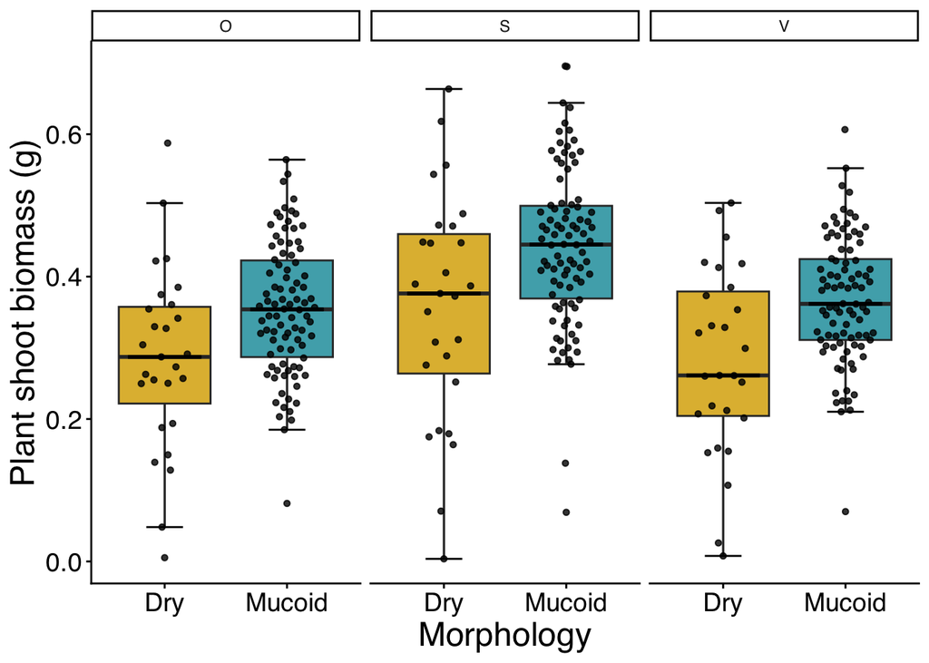

```r
### Figure: Host biomass ###


HostBiomass <- ggplot(data = Host_data_ave_all, aes(x= Morphology, y = ave_shoot, fill = Morphology)) +
stat_boxplot(geom = "errorbar", width = 0.3,position = position_dodge(width = 0.8)) +
  geom_boxplot(outlier.shape = NA, position = position_dodge(width = 0.8)) +
  stat_summary(fun = median, fun.min = median, fun.max = median,
               geom = "crossbar", width = 0.6,
               color = "black", linewidth = 0.4,
               position = position_dodge(width = 0.8)) +
    geom_quasirandom(size = 1.2, color = "black", width = 0.25, alpha = 0.8) +
        scale_fill_manual(values = color_values) +
  facet_wrap(~Variety) +
  theme_classic() +
  labs(
    x= "Morphology",
    y = "Plant shoot biomass (g)"
  ) +
  theme(
    text             = element_text(family = "Helvetica", color = "black"),
    axis.text        = element_text(size = 14, color = "black"),
    axis.title.x     = element_text(size = 18, color = "black"),
    axis.title.y     = element_text(size = 18, color = "black"),
    panel.grid       = element_blank(),
    axis.line        = element_line(color = "black"),
    axis.ticks       = element_line(color = "black"),
    legend.position  = "none")

HostBiomass
```

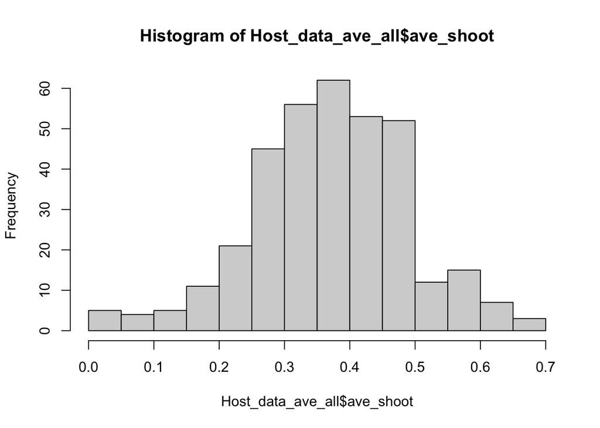

```r
ggsave(HostBiomass,
       filename = here("Phenotype", "Figures" ,"EPS_Figure4A_FromR.pdf"),
       device = "pdf",
       height = 4, width = 6, units = "in")


### Statistical analysis

hist(Host_data_ave_all$ave_shoot)
```

```r
#View(Host_data)

### Add PC1 and PC2 to Host_data file to account for them in the statistical model
#View(Phylo_inf)
#View(Host_data)
#View(plant_long)

aov_hostbiomass <- lm(ave_shoot ~ Morphology*Variety + PC1 + PC2, Host_data_ave_all)
summary(aov_hostbiomass)
```

```
##
## Call:
## lm(formula = ave_shoot ~ Morphology * Variety + PC1 + PC2, data = Host_data_ave_all)
##
## Residuals:
##      Min       1Q   Median       3Q      Max
## -0.40133 -0.05954 -0.00019  0.06683  0.27753
##
## Coefficients:
##                             Estimate Std. Error t value Pr(>|t|)
## (Intercept)                2.940e-01  2.041e-02  14.405  < 2e-16 ***
## MorphologyMucoid           5.772e-02  2.331e-02   2.477   0.0137 *
## VarietyS                   7.243e-02  2.872e-02   2.522   0.0121 *
## VarietyV                  -4.417e-03  2.872e-02  -0.154   0.8779
## PC1                        5.796e-04  1.079e-04   5.371 1.45e-07 ***
## PC2                        7.621e-05  1.662e-04   0.459   0.6468
## MorphologyMucoid:VarietyS  1.504e-02  3.275e-02   0.459   0.6464
## MorphologyMucoid:VarietyV  1.742e-02  3.275e-02   0.532   0.5952
## ---
## Signif. codes:  0 '***' 0.001 '**' 0.01 '*' 0.05 '.' 0.1 ' ' 1
##
## Residual standard error: 0.1055 on 343 degrees of freedom
## Multiple R-squared:  0.2432, Adjusted R-squared:  0.2277
## F-statistic: 15.75 on 7 and 343 DF,  p-value: < 2.2e-16
```

```r
anova_hostbiomass <- car::Anova(aov_hostbiomass, type = "II")
anova_hostbiomass <- rownames_to_column(as.data.frame(anova_hostbiomass), var = "Term")

anova_hostbiomass## Aesthetics
```

```
##                 Term      Sum Sq  Df    F value       Pr(>F)
## 1         Morphology 0.281801611   1 25.3023892 7.919702e-07
## 2            Variety 0.497714690   2 22.3443911 7.552084e-10
## 3                PC1 0.321307393   1 28.8495325 1.446072e-07
## 4                PC2 0.002343108   1  0.2103829 6.467580e-01
## 5 Morphology:Variety 0.003704067   2  0.1662903 8.468686e-01
## 6          Residuals 3.820111675 343         NA           NA
```

```r
anova_hostbiomass <- anova_hostbiomass %>%
  mutate(across(where(is.numeric) & !matches("^Df$"), ~ sprintf("%.3f", .))) %>%
  mutate(`Pr(>F)` = ifelse(as.numeric(`Pr(>F)`) < 0.001, "< 0.001", `Pr(>F)`))
anova_hostbiomass
```

```
##                 Term Sum Sq  Df F value  Pr(>F)
## 1         Morphology  0.282   1  25.302 < 0.001
## 2            Variety  0.498   2  22.344 < 0.001
## 3                PC1  0.321   1  28.850 < 0.001
## 4                PC2  0.002   1   0.210   0.647
## 5 Morphology:Variety  0.004   2   0.166   0.847
## 6          Residuals  3.820 343      NA    <NA>
```

```r
write_xlsx(anova_hostbiomass, here("Phenotype", "Tables", "EPS_TableS10A_FromR.xlsx"))
```

### Rhizobia relative fitness

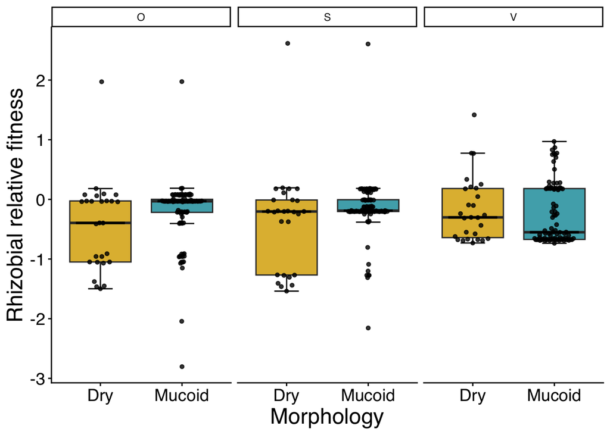

```r
#View(Host_data_ave_all)
meso_fit_ggplot <- ggplot(data = Host_data_ave_all, aes(x= Morphology, y = Fitness_ave, fill = Morphology)) +
stat_boxplot(geom = "errorbar", width = 0.3,position = position_dodge(width = 0.8)) +
  geom_boxplot(outlier.shape = NA, position = position_dodge(width = 0.8)) +
  stat_summary(fun = median, fun.min = median, fun.max = median,
               geom = "crossbar", width = 0.6,
               color = "black", linewidth = 0.4,
               position = position_dodge(width = 0.8)) +
    geom_quasirandom(size = 1.2, color = "black", width = 0.25, alpha = 0.8) +
        scale_fill_manual(values = color_values) +
  facet_wrap(~Variety) +
  theme_classic() +
  labs(
    x= "Morphology",
    y = "Rhizobial relative fitness"
  ) +
  theme(
    text             = element_text(family = "Helvetica", color = "black"),
    axis.text        = element_text(size = 14, color = "black"),
    axis.title.x     = element_text(size = 18, color = "black"),
    axis.title.y     = element_text(size = 18, color = "black"),
    panel.grid       = element_blank(),
    axis.line        = element_line(color = "black"),
    axis.ticks       = element_line(color = "black"),
    legend.position  = "none")

meso_fit_ggplot
```

```r
ggsave(meso_fit_ggplot,
       filename = here("Phenotype", "Figures" ,"EPS_Figure4B_FromR.pdf"),
       device = "pdf",
       height = 4, width = 6, units = "in")



aov_RhizobialFitness <- lm(Fitness_ave ~ Morphology*Variety + PC1 + PC2, data = Host_data_ave_all)
anova_RhizobialFitness <- car::Anova(aov_RhizobialFitness, type = 2)
anova_RhizobialFitness
```

```
## Anova Table (Type II tests)
##
## Response: Fitness_ave
##                    Sum Sq  Df F value    Pr(>F)
## Morphology          2.465   1  8.8023   0.00322 **
## Variety             0.199   2  0.3560   0.70071
## PC1                 6.459   1 23.0620 2.347e-06 ***
## PC2                 9.240   1 32.9928 2.041e-08 ***
## Morphology:Variety  1.254   2  2.2380   0.10823
## Residuals          96.066 343
## ---
## Signif. codes:  0 '***' 0.001 '**' 0.01 '*' 0.05 '.' 0.1 ' ' 1
```

```r
anova_RhizobialFitness <- rownames_to_column(as.data.frame(anova_RhizobialFitness), var = "Term") #For table formating
anova_RhizobialFitness
```

```
##                 Term    Sum Sq  Df    F value       Pr(>F)
## 1         Morphology  2.465308   1  8.8023029 3.219647e-03
## 2            Variety  0.199430   2  0.3560292 7.007107e-01
## 3                PC1  6.459105   1 23.0620296 2.347320e-06
## 4                PC2  9.240469   1 32.9928050 2.040707e-08
## 5 Morphology:Variety  1.253604   2  2.2379773 1.082295e-01
## 6          Residuals 96.065823 343         NA           NA
```

```r
anova_RhizobialFitness <- anova_RhizobialFitness %>%
  mutate(across(where(is.numeric) & !matches("^Df$"), ~ sprintf("%.3f", .))) %>%
  mutate(`Pr(>F)` = ifelse(as.numeric(`Pr(>F)`) < 0.001, "< 0.001", `Pr(>F)`))
#  dplyr::select(Term, Df, `Sum Sq`, `F value`, `Pr(>F)`)

anova_RhizobialFitness
```

```
##                 Term Sum Sq  Df F value  Pr(>F)
## 1         Morphology  2.465   1   8.802   0.003
## 2            Variety  0.199   2   0.356   0.701
## 3                PC1  6.459   1  23.062 < 0.001
## 4                PC2  9.240   1  32.993 < 0.001
## 5 Morphology:Variety  1.254   2   2.238   0.108
## 6          Residuals 96.066 343      NA    <NA>
```

```r
write_xlsx(anova_RhizobialFitness, here("Phenotype", "Tables", "EPS_TableS9A_FromR.xlsx"))

###


aov_RhizobialFitness_O <- lm(Fitness_ave ~ Morphology + PC1 + PC2, data = Host_data_ave_all %>% filter(Variety == "O"))
summary(aov_RhizobialFitness_O)
```

```
##
## Call:
## lm(formula = Fitness_ave ~ Morphology + PC1 + PC2, data = Host_data_ave_all %>%
##     filter(Variety == "O"))
##
## Residuals:
##     Min      1Q  Median      3Q     Max
## -2.6093 -0.1115  0.1141  0.3193  2.0489
##
## Coefficients:
##                   Estimate Std. Error t value Pr(>|t|)
## (Intercept)      -0.425940   0.115522  -3.687  0.00035 ***
## MorphologyMucoid  0.204101   0.132285   1.543  0.12565
## PC1               0.001462   0.001048   1.395  0.16565
## PC2               0.002175   0.001613   1.348  0.18032
## ---
## Signif. codes:  0 '***' 0.001 '**' 0.01 '*' 0.05 '.' 0.1 ' ' 1
##
## Residual standard error: 0.5915 on 113 degrees of freedom
## Multiple R-squared:  0.05571,    Adjusted R-squared:  0.03064
## F-statistic: 2.222 on 3 and 113 DF,  p-value: 0.08945
```

```r
anova_Rfit_O <- car::Anova(aov_RhizobialFitness_O, type = "II")
anova_Rfit_O
```

```
## Anova Table (Type II tests)
##
## Response: Fitness_ave
##            Sum Sq  Df F value Pr(>F)
## Morphology  0.833   1  2.3805 0.1257
## PC1         0.681   1  1.9469 0.1657
## PC2         0.636   1  1.8174 0.1803
## Residuals  39.541 113
```

```r
anova_Rfit_O <- rownames_to_column(as.data.frame(anova_Rfit_O), var = "Term") #For table formating
anova_Rfit_O <- anova_Rfit_O %>% mutate(Variety = "O")
anova_Rfit_O
```

```
##         Term     Sum Sq  Df  F value    Pr(>F) Variety
## 1 Morphology  0.8329886   1 2.380510 0.1256534       O
## 2        PC1  0.6812693   1 1.946927 0.1656545       O
## 3        PC2  0.6359380   1 1.817380 0.1803217       O
## 4  Residuals 39.5409927 113       NA        NA       O
```

```r
aov_RhizobialFitness_S <- lm(Fitness_ave ~ Morphology + PC1 + PC2, data = Host_data_ave_all %>% filter(Variety == "S"))
summary(aov_RhizobialFitness_S)
```

```
##
## Call:
## lm(formula = Fitness_ave ~ Morphology + PC1 + PC2, data = Host_data_ave_all %>%
##     filter(Variety == "S"))
##
## Residuals:
##      Min       1Q   Median       3Q      Max
## -2.17729  0.03062  0.04722  0.33562  1.44081
##
## Coefficients:
##                    Estimate Std. Error t value Pr(>|t|)
## (Intercept)      -0.4388214  0.1042721  -4.208 5.18e-05 ***
## MorphologyMucoid  0.2958198  0.1194024   2.478   0.0147 *
## PC1              -0.0016270  0.0009456  -1.721   0.0881 .
## PC2               0.0075189  0.0014561   5.164 1.05e-06 ***
## ---
## Signif. codes:  0 '***' 0.001 '**' 0.01 '*' 0.05 '.' 0.1 ' ' 1
##
## Residual standard error: 0.5339 on 113 degrees of freedom
## Multiple R-squared:  0.2228, Adjusted R-squared:  0.2022
## F-statistic:  10.8 on 3 and 113 DF,  p-value: 2.706e-06
```

```r
anova_Rfit_S <- car::Anova(aov_RhizobialFitness_S, type = "II")
anova_Rfit_S
```

```
## Anova Table (Type II tests)
##
## Response: Fitness_ave
##            Sum Sq  Df F value    Pr(>F)
## Morphology  1.750   1  6.1380   0.01471 *
## PC1         0.844   1  2.9604   0.08807 .
## PC2         7.602   1 26.6645 1.049e-06 ***
## Residuals  32.215 113
## ---
## Signif. codes:  0 '***' 0.001 '**' 0.01 '*' 0.05 '.' 0.1 ' ' 1
```

```r
anova_Rfit_S <- rownames_to_column(as.data.frame(anova_Rfit_S), var = "Term") #For table formating
anova_Rfit_S <- anova_Rfit_S %>% mutate(Variety = "S")
anova_Rfit_S
```

```
##         Term     Sum Sq  Df   F value       Pr(>F) Variety
## 1 Morphology  1.7498610   1  6.138026 1.471020e-02       S
## 2        PC1  0.8439558   1  2.960362 8.806599e-02       S
## 3        PC2  7.6016592   1 26.664506 1.049113e-06       S
## 4  Residuals 32.2146417 113        NA           NA       S
```

```r
aov_RhizobialFitness_V <- lm(Fitness_ave ~ Morphology + PC1 + PC2, data = Host_data_ave_all %>% filter(Variety == "V"))
summary(aov_RhizobialFitness_V)
```

```
##
## Call:
## lm(formula = Fitness_ave ~ Morphology + PC1 + PC2, data = Host_data_ave_all %>%
##     filter(Variety == "V"))
##
## Residuals:
##      Min       1Q   Median       3Q      Max
## -0.72339 -0.04987  0.00058  0.10524  1.07187
##
## Coefficients:
##                    Estimate Std. Error t value Pr(>|t|)
## (Intercept)      -0.3154782  0.0545012  -5.788 6.47e-08 ***
## MorphologyMucoid  0.1082446  0.0624095   1.734   0.0856 .
## PC1              -0.0076309  0.0004943 -15.439  < 2e-16 ***
## PC2               0.0046648  0.0007611   6.129 1.33e-08 ***
## ---
## Signif. codes:  0 '***' 0.001 '**' 0.01 '*' 0.05 '.' 0.1 ' ' 1
##
## Residual standard error: 0.2791 on 113 degrees of freedom
## Multiple R-squared:  0.7088, Adjusted R-squared:  0.7011
## F-statistic: 91.69 on 3 and 113 DF,  p-value: < 2.2e-16
```

```r
anova_Rfit_V <- car::Anova(aov_RhizobialFitness_V, type = "II")
anova_Rfit_V
```

```
## Anova Table (Type II tests)
##
## Response: Fitness_ave
##             Sum Sq  Df  F value    Pr(>F)
## Morphology  0.2343   1   3.0082   0.08557 .
## PC1        18.5648   1 238.3632 < 2.2e-16 ***
## PC2         2.9260   1  37.5680 1.325e-08 ***
## Residuals   8.8009 113
## ---
## Signif. codes:  0 '***' 0.001 '**' 0.01 '*' 0.05 '.' 0.1 ' ' 1
```

```r
anova_Rfit_V <- rownames_to_column(as.data.frame(anova_Rfit_V), var = "Term") #For table formating
anova_Rfit_V <- anova_Rfit_V %>% mutate(Variety = "V")
anova_Rfit_V
```

```
##         Term     Sum Sq  Df    F value       Pr(>F) Variety
## 1 Morphology  0.2342941   1   3.008227 8.556977e-02       V
## 2        PC1 18.5647811   1 238.363177 1.320171e-29       V
## 3        PC2  2.9259623   1  37.567998 1.325026e-08       V
## 4  Residuals  8.8009410 113         NA           NA       V
```

```r
Anova_RhizobialFitness_Varieties <- bind_rows(anova_Rfit_O, anova_Rfit_S, anova_Rfit_V) %>%
  mutate(across(where(is.numeric) & !matches("^Df$"), ~ sprintf("%.3f", .))) %>%
  mutate(`Pr(>F)` = ifelse(as.numeric(`Pr(>F)`) < 0.001, "< 0.001", `Pr(>F)`)) %>%
  dplyr::select(Variety, everything())
Anova_RhizobialFitness_Varieties
```

```
##    Variety       Term Sum Sq  Df F value  Pr(>F)
## 1        O Morphology  0.833   1   2.381   0.126
## 2        O        PC1  0.681   1   1.947   0.166
## 3        O        PC2  0.636   1   1.817   0.180
## 4        O  Residuals 39.541 113      NA    <NA>
## 5        S Morphology  1.750   1   6.138   0.015
## 6        S        PC1  0.844   1   2.960   0.088
## 7        S        PC2  7.602   1  26.665 < 0.001
## 8        S  Residuals 32.215 113      NA    <NA>
## 9        V Morphology  0.234   1   3.008   0.086
## 10       V        PC1 18.565   1 238.363 < 0.001
## 11       V        PC2  2.926   1  37.568 < 0.001
## 12       V  Residuals  8.801 113      NA    <NA>
```

```r
write_xlsx(Anova_RhizobialFitness_Varieties, here("Phenotype", "Tables", "EPS_TableS9B_FromR.xlsx"))
```

### Dual inoculation experiments

This compares pairs of mutants

```r
Dual_inoculation <- read_csv(here("Phenotype", "Data_input", "Dual_inoculation.csv"))
```

```
## ──────────────────────────────────────────────────────── Delimiter: "," chr
## (6): Name, Rep, Morphology, Growth_Chamber, Colonies_Dry, Colonies_Mucoid dbl
## (8): Aboveground_biomass_g, Belowground_biomass_g, Branches, Height_cm, ... lgl
## (1): ...15
```

```r
#View(Dual_inocualtion)
Dual_inoculation <- Dual_inoculation %>%
  mutate(Colonies_Dry = as.numeric(Colonies_Dry)) %>%
  mutate(Colonies_Mucoid = as.numeric(Colonies_Mucoid))
Dual_inoculation_initial <- Dual_inoculation %>% filter(Growth_Chamber == "Initial")
#View(Dual_inoculation_initial)
colnames(Dual_inoculation_initial)
```

```
##  [1] "Name"                  "Rep"                   "Morphology"
##  [4] "Growth_Chamber"        "Aboveground_biomass_g" "Belowground_biomass_g"
##  [7] "Branches"              "Height_cm"             "Number_unilobed"
## [10] "Number_twolobed"       "Number_multilobed"     "Dilution"
## [13] "Colonies_Dry"          "Colonies_Mucoid"       "...15"
```

```r
#View(Dual_inoculation_initial)
Dual_inoculation_initial_ave <- Dual_inoculation_initial %>%
  group_by(Name, Morphology) %>%
  summarise(
    colonies_ave = case_when(
      first(Morphology) == "Dry"    ~ mean(Colonies_Dry, na.rm = TRUE),
      first(Morphology) == "Mucoid" ~ mean(Colonies_Mucoid, na.rm = TRUE),
      TRUE ~ NA_real_
    ),
    .groups = "drop"
  )

Dual_inoculation_initial_ave
```

```
## # A tibble: 8 × 3
##   Name  Morphology colonies_ave
##   <chr> <chr>             <dbl>
## 1 015   Mucoid             55.2
## 2 016   Mucoid             62.6
## 3 029   Mucoid             45.4
## 4 091   Mucoid             84.2
## 5 098   Dry                46.4
## 6 099   Dry                50.4
## 7 100   Dry                42
## 8 101   Dry                54.2
```

```r
### I will build the proportion within each pair. These are the pairs; 91 - 101, 015 - 099, 016 - 100, and 029 - 098,


pair_map <- tibble::tribble(
  ~Name, ~Pairs,
  "015", "015_099",
  "099", "015_099",
  "029", "029_098",
  "098", "029_098",
  "016", "016_100",
  "100", "016_100",
  "091", "091_101",
  "101", "091_101"
)

Dual_inoculation_initial_pct <- Dual_inoculation_initial_ave %>%
  left_join(pair_map, by = "Name") %>%
  dplyr::select(Pairs, Morphology, colonies_ave) %>%
  pivot_wider(names_from = Morphology, values_from = colonies_ave) %>%
  mutate(`Percentage of Dry bacteria` = Dry / (Dry + Mucoid) * 100)

Dual_inoculation_initial_pct <- Dual_inoculation_initial_pct %>%
  rename(Name = Pairs, Percentage_Dry_initial = `Percentage of Dry bacteria`)


Harvesting_results_RPM <- Dual_inoculation  %>% filter(!Morphology %in% c("Control", "Initial")) # Remove control and NA cells
Harvesting_results_RPM <- Harvesting_results_RPM %>%
  mutate(Colonies_Dry = as.numeric(Colonies_Dry)) %>%
  mutate(Colonies_Mucoid = as.numeric(Colonies_Mucoid)) %>%
  mutate(Percentage_Dry = (Colonies_Dry/(Colonies_Dry + Colonies_Mucoid)*100)) #One plate per plant
#View(Harvesting_results_RPM)

Harvesting_results_Dual <- Harvesting_results_RPM %>% filter(Morphology == "Dual")
#View(Harvesting_results_Dual)
Harvesting_results_Dual
```

```
## # A tibble: 27 × 16
##    Name    Rep   Morphology Growth_Chamber Aboveground_biomass_g
##    <chr>   <chr> <chr>      <chr>                          <dbl>
##  1 015_099 1     Dual       1                               1.50
##  2 015_099 2     Dual       3                               2.06
##  3 015_099 3     Dual       5                               4.16
##  4 015_099 4     Dual       2                               2.11
##  5 015_099 5     Dual       4                               1.28
##  6 015_099 6     Dual       3                               2.24
##  7 015_099 7     Dual       3                               3.22
##  8 016_100 1     Dual       1                               1.91
##  9 016_100 2     Dual       5                               4.27
## 10 016_100 3     Dual       2                               3.38
## # ℹ 17 more rows
## # ℹ 11 more variables: Belowground_biomass_g <dbl>, Branches <dbl>,
## #   Height_cm <dbl>, Number_unilobed <dbl>, Number_twolobed <dbl>,
## #   Number_multilobed <dbl>, Dilution <dbl>, Colonies_Dry <dbl>,
## #   Colonies_Mucoid <dbl>, ...15 <lgl>, Percentage_Dry <dbl>
```

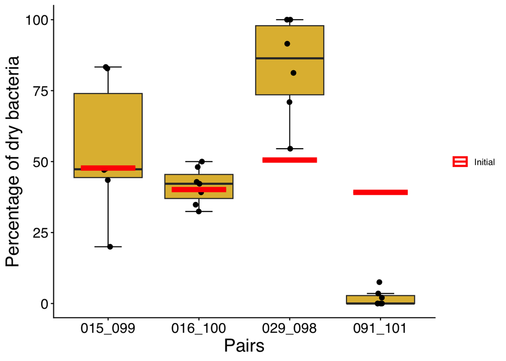

```r
Dual_Competition <- ggplot(Harvesting_results_Dual, aes(x = Name, y = Percentage_Dry)) +
  stat_boxplot(geom = "errorbar", width = 0.3, color = "black", position = position_dodge(width = 0.8)) +
  geom_boxplot(outlier.shape = NA, position = position_dodge(width = 0.8), fill = "#e0ba3e") +
  geom_jitter(position = position_jitterdodge(jitter.width = 0.15, dodge.width = 0.8), size = 2, color = "black") +
  geom_crossbar(
    data = Dual_inoculation_initial_pct,
    aes(x = Name, y = Percentage_Dry_initial,
        ymin = Percentage_Dry_initial, ymax = Percentage_Dry_initial,
        color = "Initial"),
    inherit.aes = FALSE,
    width = 0.6,
    linewidth = 1
  ) +
  scale_color_manual(name = NULL, values = c("Initial" = "red")) +
  labs(x = "Pairs", y = "Percentage of dry bacteria") +
  theme_classic() +
  theme(
    text             = element_text(family = "Helvetica", color = "black"),
    axis.text        = element_text(size = 14, color = "black"),
    axis.title.x     = element_text(size = 18, color = "black"),
    axis.title.y     = element_text(size = 18, color = "black"),
    panel.grid       = element_blank(),
    axis.line        = element_line(color = "black"),
    axis.ticks       = element_line(color = "black")
  )

Dual_Competition
```

```r
ggsave(Dual_Competition,
       filename = here("Phenotype", "Figures" ,"EPS_FigureS6_FromR.pdf"),
       device = "pdf",
       height = 4, width = 6, units = "in")
```

### Shifts from mucoid to dry in plants

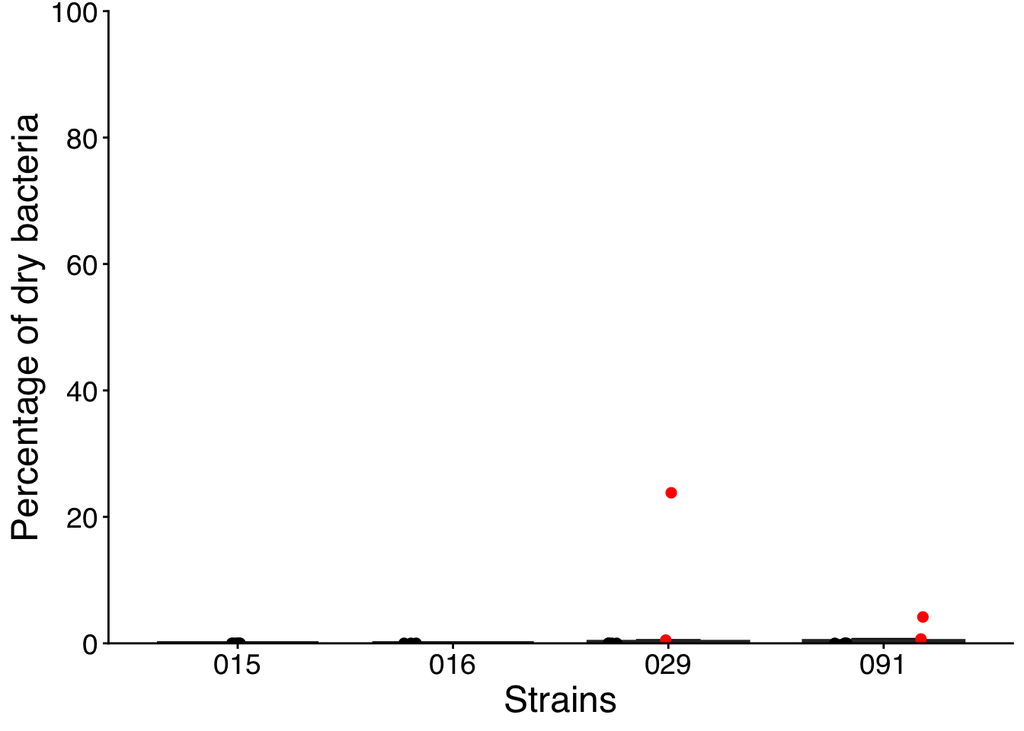

```r
Harvesting_results_Mucoid <- Harvesting_results_RPM %>% filter(Morphology == "Mucoid" & Growth_Chamber != "Initial")
#View(Harvesting_results_Mucoid)


Shift_InPlant <- ggplot(Harvesting_results_Mucoid %>%
                           mutate(Highlight = if_else(Percentage_Dry > 0, "red_dot", "normal")),
                         aes(x = Name, y = Percentage_Dry)) +
  stat_boxplot(geom = "errorbar", width = 0.3, color = "black", position = position_dodge(width = 0.8)) +
  geom_boxplot(outlier.shape = NA, position = position_dodge(width = 0.8), fill = "#e0ba3e") +
  geom_jitter(aes(color = Highlight),
              position = position_jitterdodge(jitter.width = 0.15, dodge.width = 0.8),
              size = 2) +
  scale_color_manual(values = c("normal" = "black", "red_dot" = "red")) +
  scale_y_continuous(limits = c(0, 100), breaks = seq(0, 100, 20), expand = c(0, 0)) +
  labs(x = "Strains", y = "Percentage of dry bacteria") +
  theme_classic() +
  theme(
    text             = element_text(family = "Helvetica", color = "black"),
    axis.text        = element_text(size = 14, color = "black"),
    axis.title.x     = element_text(size = 18, color = "black"),
    axis.title.y     = element_text(size = 18, color = "black"),
    panel.grid       = element_blank(),
    axis.line        = element_line(color = "black"),
    axis.ticks       = element_line(color = "black"),
    legend.position  = "none"
  )
Shift_InPlant
```

```r
ggsave(Shift_InPlant,
       filename = here("Phenotype", "Figures" ,"EPS_FigureS7_FromR.pdf"),
       device = "pdf",
       height = 4, width = 6, units = "in")
```

#### Other plant traits

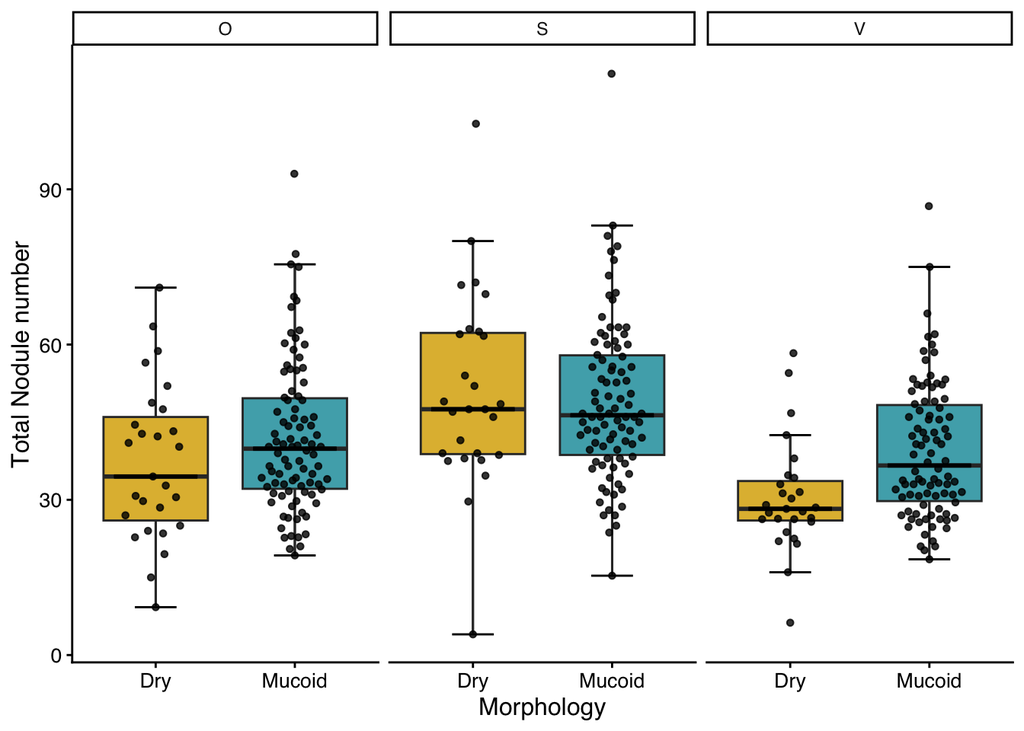

```r
#### Nodule number


Host_NoduleTotal <- ggplot(data = Host_data_ave_all, aes(x= Morphology, y = ave_nod_total, fill = Morphology)) +
stat_boxplot(geom = "errorbar", width = 0.3,position = position_dodge(width = 0.8)) +
  geom_boxplot(outlier.shape = NA, position = position_dodge(width = 0.8)) +
  stat_summary(fun = median, fun.min = median, fun.max = median,
               geom = "crossbar", width = 0.6,
               color = "black", linewidth = 0.4,
               position = position_dodge(width = 0.8)) +
    geom_quasirandom(size = 1.2, color = "black", width = 0.25, alpha = 0.8) +
        scale_fill_manual(values = color_values) +
  facet_wrap(~Variety) +
  theme_classic() +
  labs(
    x= "Morphology",
    y = "Total Nodule number"
  ) +
  theme(
    text             = element_text(family = "Helvetica", color = "black"),
    axis.text        = element_text(size = 10, color = "black"),
    axis.title.x     = element_text(size = 12, color = "black"),
    axis.title.y     = element_text(size = 12, color = "black"),
    panel.grid       = element_blank(),
    axis.line        = element_line(color = "black"),
    axis.ticks       = element_line(color = "black"),
    legend.position  = "none")

Host_NoduleTotal
```

```r
ggsave(Host_NoduleTotal,
       filename = here("Phenotype", "Figures" ,"EPS_FigureS8A_FromR.pdf"),
       device = "pdf",
       height = 3, width = 4, units = "in")

#View(Host_all)
#View(Host_data_ave_all)

aov_hostnodtotal <- lm(ave_nod_total ~ Morphology*Variety + PC1 + PC2, Host_data_ave_all)
summary(aov_hostbiomass)
```

```
##
## Call:
## lm(formula = ave_shoot ~ Morphology * Variety + PC1 + PC2, data = Host_data_ave_all)
##
## Residuals:
##      Min       1Q   Median       3Q      Max
## -0.40133 -0.05954 -0.00019  0.06683  0.27753
##
## Coefficients:
##                             Estimate Std. Error t value Pr(>|t|)
## (Intercept)                2.940e-01  2.041e-02  14.405  < 2e-16 ***
## MorphologyMucoid           5.772e-02  2.331e-02   2.477   0.0137 *
## VarietyS                   7.243e-02  2.872e-02   2.522   0.0121 *
## VarietyV                  -4.417e-03  2.872e-02  -0.154   0.8779
## PC1                        5.796e-04  1.079e-04   5.371 1.45e-07 ***
## PC2                        7.621e-05  1.662e-04   0.459   0.6468
## MorphologyMucoid:VarietyS  1.504e-02  3.275e-02   0.459   0.6464
## MorphologyMucoid:VarietyV  1.742e-02  3.275e-02   0.532   0.5952
## ---
## Signif. codes:  0 '***' 0.001 '**' 0.01 '*' 0.05 '.' 0.1 ' ' 1
##
## Residual standard error: 0.1055 on 343 degrees of freedom
## Multiple R-squared:  0.2432, Adjusted R-squared:  0.2277
## F-statistic: 15.75 on 7 and 343 DF,  p-value: < 2.2e-16
```

```r
anova_hostnodtotal <- car::Anova(aov_hostnodtotal, type = "II")
anova_hostnodtotal <- rownames_to_column(as.data.frame(anova_hostnodtotal), var = "Term")

anova_hostnodtotal
```

```
##                 Term     Sum Sq  Df   F value       Pr(>F)
## 1         Morphology  1822.2860   1  8.972711 2.939762e-03
## 2            Variety  9068.8392   2 22.326921 7.669726e-10
## 3                PC1  3168.5942   1 15.601766 9.491782e-05
## 4                PC2   763.7177   1  3.760452 5.329820e-02
## 5 Morphology:Variety  1293.3767   2  3.184213 4.263781e-02
## 6          Residuals 69660.5652 343        NA           NA
```

```r
anova_hostnodtotal <- anova_hostnodtotal %>%
  mutate(across(where(is.numeric) & !matches("^Df$"), ~ sprintf("%.3f", .))) %>%
  mutate(`Pr(>F)` = ifelse(as.numeric(`Pr(>F)`) < 0.001, "< 0.001", `Pr(>F)`))
anova_hostnodtotal
```

```
##                 Term    Sum Sq  Df F value  Pr(>F)
## 1         Morphology  1822.286   1   8.973   0.003
## 2            Variety  9068.839   2  22.327 < 0.001
## 3                PC1  3168.594   1  15.602 < 0.001
## 4                PC2   763.718   1   3.760   0.053
## 5 Morphology:Variety  1293.377   2   3.184   0.043
## 6          Residuals 69660.565 343      NA    <NA>
```

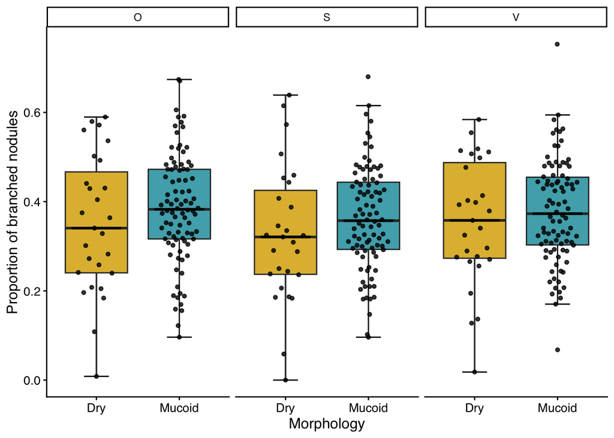

```r
write_xlsx(anova_hostnodtotal, here("Phenotype", "Tables", "EPS_TableS10B_FromR.xlsx"))



#### Branching

Host_Branching <- ggplot(data = Host_data_ave_all, aes(x= Morphology, y = ave_prop_branched, fill = Morphology)) +
stat_boxplot(geom = "errorbar", width = 0.3,position = position_dodge(width = 0.8)) +
  geom_boxplot(outlier.shape = NA, position = position_dodge(width = 0.8)) +
  stat_summary(fun = median, fun.min = median, fun.max = median,
               geom = "crossbar", width = 0.6,
               color = "black", linewidth = 0.4,
               position = position_dodge(width = 0.8)) +
    geom_quasirandom(size = 1.2, color = "black", width = 0.25, alpha = 0.8) +
        scale_fill_manual(values = color_values) +
  facet_wrap(~Variety) +
  theme_classic() +
  labs(
    x= "Morphology",
    y = "Proportion of branched nodules"
  ) +
  theme(
    text             = element_text(family = "Helvetica", color = "black"),
    axis.text        = element_text(size = 10, color = "black"),
    axis.title.x     = element_text(size = 12, color = "black"),
    axis.title.y     = element_text(size = 12, color = "black"),
    panel.grid       = element_blank(),
    axis.line        = element_line(color = "black"),
    axis.ticks       = element_line(color = "black"),
    legend.position  = "none")

Host_Branching
```

```r
ggsave(Host_Branching,
       filename = here("Phenotype", "Figures" ,"EPS_FigureS8B_FromR.pdf"),
       device = "pdf",
       height = 3, width = 4, units = "in")

#View(Host_data_ave_all)
aov_hostBranching <- lm(ave_prop_branched ~ Morphology*Variety + PC1 + PC2, Host_data_ave_all)
summary(aov_hostbiomass)
```

```
##
## Call:
## lm(formula = ave_shoot ~ Morphology * Variety + PC1 + PC2, data = Host_data_ave_all)
##
## Residuals:
##      Min       1Q   Median       3Q      Max
## -0.40133 -0.05954 -0.00019  0.06683  0.27753
##
## Coefficients:
##                             Estimate Std. Error t value Pr(>|t|)
## (Intercept)                2.940e-01  2.041e-02  14.405  < 2e-16 ***
## MorphologyMucoid           5.772e-02  2.331e-02   2.477   0.0137 *
## VarietyS                   7.243e-02  2.872e-02   2.522   0.0121 *
## VarietyV                  -4.417e-03  2.872e-02  -0.154   0.8779
## PC1                        5.796e-04  1.079e-04   5.371 1.45e-07 ***
## PC2                        7.621e-05  1.662e-04   0.459   0.6468
## MorphologyMucoid:VarietyS  1.504e-02  3.275e-02   0.459   0.6464
## MorphologyMucoid:VarietyV  1.742e-02  3.275e-02   0.532   0.5952
## ---
## Signif. codes:  0 '***' 0.001 '**' 0.01 '*' 0.05 '.' 0.1 ' ' 1
##
## Residual standard error: 0.1055 on 343 degrees of freedom
## Multiple R-squared:  0.2432, Adjusted R-squared:  0.2277
## F-statistic: 15.75 on 7 and 343 DF,  p-value: < 2.2e-16
```

```r
anova_aov_hostBranching <- car::Anova(aov_hostBranching, type = "II")
anova_aov_hostBranching <- rownames_to_column(as.data.frame(anova_aov_hostBranching), var = "Term")

anova_aov_hostBranching
```

```
##                 Term      Sum Sq  Df     F value       Pr(>F)
## 1         Morphology 0.012844706   1  0.88519982 3.474436e-01
## 2            Variety 0.035074161   2  1.20857733 2.998902e-01
## 3                PC1 0.456325738   1 31.44793342 4.220820e-08
## 4                PC2 0.055141110   1  3.80007925 5.206487e-02
## 5 Morphology:Variety 0.002488503   2  0.08574825 9.178449e-01
## 6          Residuals 4.977106950 343          NA           NA
```

```r
anova_aov_hostBranching <- anova_aov_hostBranching %>%
  mutate(across(where(is.numeric) & !matches("^Df$"), ~ sprintf("%.3f", .))) %>%
  mutate(`Pr(>F)` = ifelse(as.numeric(`Pr(>F)`) < 0.001, "< 0.001", `Pr(>F)`))
anova_aov_hostBranching
```

```
##                 Term Sum Sq  Df F value  Pr(>F)
## 1         Morphology  0.013   1   0.885   0.347
## 2            Variety  0.035   2   1.209   0.300
## 3                PC1  0.456   1  31.448 < 0.001
## 4                PC2  0.055   1   3.800   0.052
## 5 Morphology:Variety  0.002   2   0.086   0.918
## 6          Residuals  4.977 343      NA    <NA>
```

```r
write_xlsx(anova_aov_hostBranching, here("Phenotype", "Tables", "EPS_TableS10C_FromR.xlsx"))
```